Colegio Universitario de Cartago

Big Data – BD-142 Exploración de Datos

Examen Final

Análisis Exploratorio de Datos

**Grupo:** #2

**Dataset:** Wine Clustering

**Profesor:** [Ronald Cordoba Vega](https://www.cucvirtual.ac.cr/user/view.php?id=11192&course=2375)

### Integrantes

Bermúdez Rodríguez, Desmond Akin

Calderón Vega, Andrei

Cambronero Zúñiga, Carlos Alberto

Jiménez Portuguez, Samiel

Ramírez Pérez, Jeremy

**Fecha de entrega:** 17 de agosto de 2026

# 1 Análisis preexploratorio

## 1.1 Descripción inicial del problema

El dataset **Wine Clustering** contiene diferentes mediciones químicas de muestras de vino.  
Antes de realizar el análisis exploratorio y aplicar un modelo de clustering, es necesario conocer cómo vienen los datos, revisar su calidad y detectar características que puedan ser importantes para las siguientes etapas del análisis.

## 1.2 Objetivo del análisis

Realizar un análisis preexploratorio del dataset para conocer su estructura, calidad, estadísticas principales, dispersión y posibles valores atípicos. Los resultados obtenidos servirán posteriormente para plantear preguntas específicas que serán investigadas en el EDA.

## 1.3 Carga de datos

### 1.3.1 Importación del dataset

```r
# Ruta del dataset
ruta_dataset <- "../Data/archive/wine-clustering.csv"

# Verificar que el archivo exista
if (!file.exists(ruta_dataset)) {
  stop("No se encontró el archivo wine-clustering.csv.")
}

# Cargar dataset
wine <- read.csv(
  ruta_dataset,
  stringsAsFactors = FALSE,
  check.names = FALSE
)

cat("Dataset cargado correctamente.")
```

```
## Dataset cargado correctamente.
```

### 1.3.2 Dimensiones del dataset

```r
cat("Cantidad de filas:", nrow(wine), "\n")
```

```
## Cantidad de filas: 178
```

```r
cat("Cantidad de columnas:", ncol(wine))
```

```
## Cantidad de columnas: 13
```

### 1.3.3 Variables del dataset

```r
names(wine)
```

```
##  [1] "Alcohol"              "Malic_Acid"           "Ash"
##  [4] "Ash_Alcanity"         "Magnesium"            "Total_Phenols"
##  [7] "Flavanoids"           "Nonflavanoid_Phenols" "Proanthocyanins"
## [10] "Color_Intensity"      "Hue"                  "OD280"
## [13] "Proline"
```

### 1.3.4 Tipos de variables

```r
sapply(wine, class)
```

```
##              Alcohol           Malic_Acid                  Ash
##            "numeric"            "numeric"            "numeric"
##         Ash_Alcanity            Magnesium        Total_Phenols
##            "numeric"            "integer"            "numeric"
##           Flavanoids Nonflavanoid_Phenols      Proanthocyanins
##            "numeric"            "numeric"            "numeric"
##      Color_Intensity                  Hue                OD280
##            "numeric"            "numeric"            "numeric"
##              Proline
##            "integer"
```

## 1.4 Cantidad de variables numéricas

```r
cantidad_numericas <- sum(sapply(wine, is.numeric))

cat("Variables numéricas:", cantidad_numericas, "\n")
```

```
## Variables numéricas: 13
```

```r
cat("Total de variables:", ncol(wine))
```

```
## Total de variables: 13
```

## 1.5 Calidad inicial de los datos

### 1.5.1 Valores faltantes

```r
faltantes <- sum(is.na(wine))

cat("Cantidad total de valores faltantes:", faltantes)
```

```
## Cantidad total de valores faltantes: 0
```

### 1.5.2 Valores faltantes por variable

```r
colSums(is.na(wine))
```

```
##              Alcohol           Malic_Acid                  Ash
##                    0                    0                    0
##         Ash_Alcanity            Magnesium        Total_Phenols
##                    0                    0                    0
##           Flavanoids Nonflavanoid_Phenols      Proanthocyanins
##                    0                    0                    0
##      Color_Intensity                  Hue                OD280
##                    0                    0                    0
##              Proline
##                    0
```

### 1.5.3 Registros duplicados

```r
duplicados <- sum(duplicated(wine))

cat("Cantidad de registros duplicados:", duplicados)
```

```
## Cantidad de registros duplicados: 0
```

### 1.5.4 Porcentaje de registros duplicados

```r
porcentaje_duplicados <- (duplicados / nrow(wine)) * 100

cat("Porcentaje de duplicados:", round(porcentaje_duplicados, 2), "%")
```

```
## Porcentaje de duplicados: 0 %
```

## 1.6 Estadísticas descriptivas iniciales

### 1.6.1 Resumen general del dataset

```r
summary(wine)
```

```
##     Alcohol        Malic_Acid         Ash         Ash_Alcanity
##  Min.   :11.03   Min.   :0.740   Min.   :1.360   Min.   :10.60
##  1st Qu.:12.36   1st Qu.:1.603   1st Qu.:2.210   1st Qu.:17.20
##  Median :13.05   Median :1.865   Median :2.360   Median :19.50
##  Mean   :13.00   Mean   :2.336   Mean   :2.367   Mean   :19.49
##  3rd Qu.:13.68   3rd Qu.:3.083   3rd Qu.:2.558   3rd Qu.:21.50
##  Max.   :14.83   Max.   :5.800   Max.   :3.230   Max.   :30.00
##    Magnesium      Total_Phenols     Flavanoids    Nonflavanoid_Phenols
##  Min.   : 70.00   Min.   :0.980   Min.   :0.340   Min.   :0.1300
##  1st Qu.: 88.00   1st Qu.:1.742   1st Qu.:1.205   1st Qu.:0.2700
##  Median : 98.00   Median :2.355   Median :2.135   Median :0.3400
##  Mean   : 99.74   Mean   :2.295   Mean   :2.029   Mean   :0.3619
##  3rd Qu.:107.00   3rd Qu.:2.800   3rd Qu.:2.875   3rd Qu.:0.4375
##  Max.   :162.00   Max.   :3.880   Max.   :5.080   Max.   :0.6600
##  Proanthocyanins Color_Intensity       Hue             OD280
##  Min.   :0.410   Min.   : 1.280   Min.   :0.4800   Min.   :1.270
##  1st Qu.:1.250   1st Qu.: 3.220   1st Qu.:0.7825   1st Qu.:1.938
##  Median :1.555   Median : 4.690   Median :0.9650   Median :2.780
##  Mean   :1.591   Mean   : 5.058   Mean   :0.9574   Mean   :2.612
##  3rd Qu.:1.950   3rd Qu.: 6.200   3rd Qu.:1.1200   3rd Qu.:3.170
##  Max.   :3.580   Max.   :13.000   Max.   :1.7100   Max.   :4.000
##     Proline
##  Min.   : 278.0
##  1st Qu.: 500.5
##  Median : 673.5
##  Mean   : 746.9
##  3rd Qu.: 985.0
##  Max.   :1680.0
```

El resumen permite observar el mínimo, primer cuartil, mediana, promedio, tercer cuartil y máximo de cada variable.

### 1.6.2 Promedios

```r
promedios <- colMeans(wine, na.rm = TRUE)

round(promedios, 2)
```

```
##              Alcohol           Malic_Acid                  Ash
##                13.00                 2.34                 2.37
##         Ash_Alcanity            Magnesium        Total_Phenols
##                19.49                99.74                 2.30
##           Flavanoids Nonflavanoid_Phenols      Proanthocyanins
##                 2.03                 0.36                 1.59
##      Color_Intensity                  Hue                OD280
##                 5.06                 0.96                 2.61
##              Proline
##               746.89
```

### 1.6.3 Medianas

```r
medianas <- sapply(wine, median, na.rm = TRUE)

round(medianas, 2)
```

```
##              Alcohol           Malic_Acid                  Ash
##                13.05                 1.87                 2.36
##         Ash_Alcanity            Magnesium        Total_Phenols
##                19.50                98.00                 2.36
##           Flavanoids Nonflavanoid_Phenols      Proanthocyanins
##                 2.13                 0.34                 1.56
##      Color_Intensity                  Hue                OD280
##                 4.69                 0.96                 2.78
##              Proline
##               673.50
```

### 1.6.4 Desviación estándar

```r
desviaciones <- sapply(wine, sd, na.rm = TRUE)

round(desviaciones, 2)
```

```
##              Alcohol           Malic_Acid                  Ash
##                 0.81                 1.12                 0.27
##         Ash_Alcanity            Magnesium        Total_Phenols
##                 3.34                14.28                 0.63
##           Flavanoids Nonflavanoid_Phenols      Proanthocyanins
##                 1.00                 0.12                 0.57
##      Color_Intensity                  Hue                OD280
##                 2.32                 0.23                 0.71
##              Proline
##               314.91
```

La desviación estándar permite conocer qué tanto se alejan los datos del promedio de cada variable.

### 1.6.5 Rango de las variables

```r
rangos <- sapply(wine, function(x) {
  max(x, na.rm = TRUE) - min(x, na.rm = TRUE)
})

round(rangos, 2)
```

```
##              Alcohol           Malic_Acid                  Ash
##                 3.80                 5.06                 1.87
##         Ash_Alcanity            Magnesium        Total_Phenols
##                19.40                92.00                 2.90
##           Flavanoids Nonflavanoid_Phenols      Proanthocyanins
##                 4.74                 0.53                 3.17
##      Color_Intensity                  Hue                OD280
##                11.72                 1.23                 2.73
##              Proline
##              1402.00
```

El rango permite conocer la diferencia entre el valor mínimo y máximo de cada variable.

## 1.7 Detección numérica de posibles valores atípicos

### 1.7.1 Cantidad de outliers por variable

```r
# Función sencilla para contar outliers con el método IQR
contar_outliers <- function(x) {

  Q1 <- quantile(x, 0.25, na.rm = TRUE)
  Q3 <- quantile(x, 0.75, na.rm = TRUE)

  IQR_valor <- Q3 - Q1

  limite_inferior <- Q1 - 1.5 * IQR_valor
  limite_superior <- Q3 + 1.5 * IQR_valor

  sum(
    x < limite_inferior | x > limite_superior,
    na.rm = TRUE
  )
}

outliers <- sapply(wine, contar_outliers)

outliers
```

```
##              Alcohol           Malic_Acid                  Ash
##                    0                    3                    3
##         Ash_Alcanity            Magnesium        Total_Phenols
##                    4                    4                    0
##           Flavanoids Nonflavanoid_Phenols      Proanthocyanins
##                    0                    0                    2
##      Color_Intensity                  Hue                OD280
##                    4                    1                    0
##              Proline
##                    0
```

### 1.7.2 Porcentaje de outliers por variable

```r
porcentaje_outliers <- (outliers / nrow(wine)) * 100

round(porcentaje_outliers, 2)
```

```
##              Alcohol           Malic_Acid                  Ash
##                 0.00                 1.69                 1.69
##         Ash_Alcanity            Magnesium        Total_Phenols
##                 2.25                 2.25                 0.00
##           Flavanoids Nonflavanoid_Phenols      Proanthocyanins
##                 0.00                 0.00                 1.12
##      Color_Intensity                  Hue                OD280
##                 2.25                 0.56                 0.00
##              Proline
##                 0.00
```

Este resultado permite observar cuáles variables presentan mayor cantidad de posibles valores atípicos.

## 1.8 Comparación de datos con y sin posibles outliers

### 1.8.1 Crear una versión temporal sin outliers

```r
# Inicialmente todas las filas se consideran válidas
filas_validas <- rep(TRUE, nrow(wine))

# Revisar cada variable
for (columna in names(wine)) {

  Q1 <- quantile(wine[[columna]], 0.25, na.rm = TRUE)
  Q3 <- quantile(wine[[columna]], 0.75, na.rm = TRUE)

  IQR_valor <- Q3 - Q1

  limite_inferior <- Q1 - 1.5 * IQR_valor
  limite_superior <- Q3 + 1.5 * IQR_valor

  filas_validas <- filas_validas &
    wine[[columna]] >= limite_inferior &
    wine[[columna]] <= limite_superior
}

# Crear dataset temporal sin posibles outliers
wine_sin_outliers <- wine[filas_validas, ]

cat("Filas originales:", nrow(wine), "\n")
```

```
## Filas originales: 178
```

```r
cat("Filas sin posibles outliers:", nrow(wine_sin_outliers), "\n")
```

```
## Filas sin posibles outliers: 161
```

```r
cat("Filas con algún posible outlier:",
    nrow(wine) - nrow(wine_sin_outliers))
```

```
## Filas con algún posible outlier: 17
```

Esta versión del dataset se utiliza únicamente para comparar el efecto de los posibles valores atípicos. No significa que estos datos serán eliminados definitivamente.

## 1.9 Comparación de estadísticas

### 1.9.1 Resumen del dataset original

```r
summary(wine)
```

```
##     Alcohol        Malic_Acid         Ash         Ash_Alcanity
##  Min.   :11.03   Min.   :0.740   Min.   :1.360   Min.   :10.60
##  1st Qu.:12.36   1st Qu.:1.603   1st Qu.:2.210   1st Qu.:17.20
##  Median :13.05   Median :1.865   Median :2.360   Median :19.50
##  Mean   :13.00   Mean   :2.336   Mean   :2.367   Mean   :19.49
##  3rd Qu.:13.68   3rd Qu.:3.083   3rd Qu.:2.558   3rd Qu.:21.50
##  Max.   :14.83   Max.   :5.800   Max.   :3.230   Max.   :30.00
##    Magnesium      Total_Phenols     Flavanoids    Nonflavanoid_Phenols
##  Min.   : 70.00   Min.   :0.980   Min.   :0.340   Min.   :0.1300
##  1st Qu.: 88.00   1st Qu.:1.742   1st Qu.:1.205   1st Qu.:0.2700
##  Median : 98.00   Median :2.355   Median :2.135   Median :0.3400
##  Mean   : 99.74   Mean   :2.295   Mean   :2.029   Mean   :0.3619
##  3rd Qu.:107.00   3rd Qu.:2.800   3rd Qu.:2.875   3rd Qu.:0.4375
##  Max.   :162.00   Max.   :3.880   Max.   :5.080   Max.   :0.6600
##  Proanthocyanins Color_Intensity       Hue             OD280
##  Min.   :0.410   Min.   : 1.280   Min.   :0.4800   Min.   :1.270
##  1st Qu.:1.250   1st Qu.: 3.220   1st Qu.:0.7825   1st Qu.:1.938
##  Median :1.555   Median : 4.690   Median :0.9650   Median :2.780
##  Mean   :1.591   Mean   : 5.058   Mean   :0.9574   Mean   :2.612
##  3rd Qu.:1.950   3rd Qu.: 6.200   3rd Qu.:1.1200   3rd Qu.:3.170
##  Max.   :3.580   Max.   :13.000   Max.   :1.7100   Max.   :4.000
##     Proline
##  Min.   : 278.0
##  1st Qu.: 500.5
##  Median : 673.5
##  Mean   : 746.9
##  3rd Qu.: 985.0
##  Max.   :1680.0
```

### 1.9.2 Resumen sin posibles outliers

```r
summary(wine_sin_outliers)
```

```
##     Alcohol        Malic_Acid         Ash         Ash_Alcanity
##  Min.   :11.41   Min.   :0.740   Min.   :1.700   Min.   :11.20
##  1st Qu.:12.37   1st Qu.:1.610   1st Qu.:2.230   1st Qu.:17.10
##  Median :13.07   Median :1.860   Median :2.360   Median :19.00
##  Mean   :13.04   Mean   :2.307   Mean   :2.363   Mean   :19.23
##  3rd Qu.:13.71   3rd Qu.:3.030   3rd Qu.:2.530   3rd Qu.:21.00
##  Max.   :14.83   Max.   :5.190   Max.   :2.920   Max.   :27.00
##    Magnesium      Total_Phenols    Flavanoids    Nonflavanoid_Phenols
##  Min.   : 70.00   Min.   :0.98   Min.   :0.340   Min.   :0.1300
##  1st Qu.: 88.00   1st Qu.:1.72   1st Qu.:1.220   1st Qu.:0.2700
##  Median : 98.00   Median :2.35   Median :2.140   Median :0.3400
##  Mean   : 98.53   Mean   :2.29   Mean   :2.044   Mean   :0.3581
##  3rd Qu.:106.00   3rd Qu.:2.80   3rd Qu.:2.910   3rd Qu.:0.4300
##  Max.   :134.00   Max.   :3.88   Max.   :3.930   Max.   :0.6600
##  Proanthocyanins Color_Intensity       Hue             OD280
##  Min.   :0.410   Min.   : 1.280   Min.   :0.5400   Min.   :1.270
##  1st Qu.:1.240   1st Qu.: 3.270   1st Qu.:0.7900   1st Qu.:2.010
##  Median :1.530   Median : 4.800   Median :0.9800   Median :2.780
##  Mean   :1.548   Mean   : 5.014   Mean   :0.9591   Mean   :2.629
##  3rd Qu.:1.870   3rd Qu.: 6.200   3rd Qu.:1.1200   3rd Qu.:3.180
##  Max.   :2.960   Max.   :10.520   Max.   :1.4500   Max.   :4.000
##     Proline
##  Min.   : 278.0
##  1st Qu.: 502.0
##  Median : 675.0
##  Mean   : 759.1
##  3rd Qu.:1035.0
##  Max.   :1680.0
```

### 1.9.3 Comparación de promedios

```r
promedio_original <- colMeans(wine, na.rm = TRUE)

promedio_sin_outliers <- colMeans(
  wine_sin_outliers,
  na.rm = TRUE
)

comparacion_promedios <- data.frame(
  Variable = names(wine),
  Promedio_Original = round(promedio_original, 2),
  Promedio_Sin_Outliers = round(promedio_sin_outliers, 2)
)

comparacion_promedios
```

|  | Variable | Promedio_Original | Promedio_Sin_Outliers |
| --- | --- | --- | --- |
| Alcohol | Alcohol | 13.00 | 13.04 |
| Malic_Acid | Malic_Acid | 2.34 | 2.31 |
| Ash | Ash | 2.37 | 2.36 |
| Ash_Alcanity | Ash_Alcanity | 19.49 | 19.23 |
| Magnesium | Magnesium | 99.74 | 98.53 |
| Total_Phenols | Total_Phenols | 2.30 | 2.29 |
| Flavanoids | Flavanoids | 2.03 | 2.04 |
| Nonflavanoid_Phenols | Nonflavanoid_Phenols | 0.36 | 0.36 |
| Proanthocyanins | Proanthocyanins | 1.59 | 1.55 |
| Color_Intensity | Color_Intensity | 5.06 | 5.01 |
| Hue | Hue | 0.96 | 0.96 |
| OD280 | OD280 | 2.61 | 2.63 |
| Proline | Proline | 746.89 | 759.11 |

### 1.9.4 Cambio porcentual de los promedios

```r
cambio_promedio <- abs(
  (promedio_sin_outliers - promedio_original) /
  promedio_original
) * 100

comparacion_promedios$Cambio_Porcentual <- round(
  cambio_promedio,
  2
)

comparacion_promedios
```

|  | Variable | Promedio_Original | Promedio_Sin_Outliers | Cambio_Porcentual |
| --- | --- | --- | --- | --- |
| Alcohol | Alcohol | 13.00 | 13.04 | 0.31 |
| Malic_Acid | Malic_Acid | 2.34 | 2.31 | 1.26 |
| Ash | Ash | 2.37 | 2.36 | 0.14 |
| Ash_Alcanity | Ash_Alcanity | 19.49 | 19.23 | 1.35 |
| Magnesium | Magnesium | 99.74 | 98.53 | 1.21 |
| Total_Phenols | Total_Phenols | 2.30 | 2.29 | 0.21 |
| Flavanoids | Flavanoids | 2.03 | 2.04 | 0.72 |
| Nonflavanoid_Phenols | Nonflavanoid_Phenols | 0.36 | 0.36 | 1.03 |
| Proanthocyanins | Proanthocyanins | 1.59 | 1.55 | 2.69 |
| Color_Intensity | Color_Intensity | 5.06 | 5.01 | 0.87 |
| Hue | Hue | 0.96 | 0.96 | 0.17 |
| OD280 | OD280 | 2.61 | 2.63 | 0.66 |
| Proline | Proline | 746.89 | 759.11 | 1.64 |

El cambio porcentual permite observar cuáles variables modifican más su promedio cuando se excluyen temporalmente los posibles valores atípicos.

### 1.9.5 Comparación de medianas

```r
mediana_original <- sapply(
  wine,
  median,
  na.rm = TRUE
)

mediana_sin_outliers <- sapply(
  wine_sin_outliers,
  median,
  na.rm = TRUE
)

comparacion_medianas <- data.frame(
  Variable = names(wine),
  Mediana_Original = round(mediana_original, 2),
  Mediana_Sin_Outliers = round(mediana_sin_outliers, 2)
)

comparacion_medianas
```

|  | Variable | Mediana_Original | Mediana_Sin_Outliers |
| --- | --- | --- | --- |
| Alcohol | Alcohol | 13.05 | 13.07 |
| Malic_Acid | Malic_Acid | 1.87 | 1.86 |
| Ash | Ash | 2.36 | 2.36 |
| Ash_Alcanity | Ash_Alcanity | 19.50 | 19.00 |
| Magnesium | Magnesium | 98.00 | 98.00 |
| Total_Phenols | Total_Phenols | 2.36 | 2.35 |
| Flavanoids | Flavanoids | 2.13 | 2.14 |
| Nonflavanoid_Phenols | Nonflavanoid_Phenols | 0.34 | 0.34 |
| Proanthocyanins | Proanthocyanins | 1.56 | 1.53 |
| Color_Intensity | Color_Intensity | 4.69 | 4.80 |
| Hue | Hue | 0.96 | 0.98 |
| OD280 | OD280 | 2.78 | 2.78 |
| Proline | Proline | 673.50 | 675.00 |

### 1.9.6 Comparación de desviaciones estándar

```r
desviacion_original <- sapply(
  wine,
  sd,
  na.rm = TRUE
)

desviacion_sin_outliers <- sapply(
  wine_sin_outliers,
  sd,
  na.rm = TRUE
)

comparacion_desviacion <- data.frame(
  Variable = names(wine),
  Desviacion_Original = round(desviacion_original, 2),
  Desviacion_Sin_Outliers = round(desviacion_sin_outliers, 2)
)

comparacion_desviacion
```

|  | Variable | Desviacion_Original | Desviacion_Sin_Outliers |
| --- | --- | --- | --- |
| Alcohol | Alcohol | 0.81 | 0.80 |
| Malic_Acid | Malic_Acid | 1.12 | 1.05 |
| Ash | Ash | 0.27 | 0.24 |
| Ash_Alcanity | Ash_Alcanity | 3.34 | 3.01 |
| Magnesium | Magnesium | 14.28 | 12.37 |
| Total_Phenols | Total_Phenols | 0.63 | 0.63 |
| Flavanoids | Flavanoids | 1.00 | 0.99 |
| Nonflavanoid_Phenols | Nonflavanoid_Phenols | 0.12 | 0.12 |
| Proanthocyanins | Proanthocyanins | 0.57 | 0.53 |
| Color_Intensity | Color_Intensity | 2.32 | 2.12 |
| Hue | Hue | 0.23 | 0.22 |
| OD280 | OD280 | 0.71 | 0.71 |
| Proline | Proline | 314.91 | 323.87 |

## 1.10 Revisión de diferencias de escala

### 1.10.1 Valores mínimos, máximos y rango

```r
minimos <- sapply(wine, min, na.rm = TRUE)
maximos <- sapply(wine, max, na.rm = TRUE)

escalas <- data.frame(
  Variable = names(wine),
  Minimo = round(minimos, 2),
  Maximo = round(maximos, 2),
  Rango = round(maximos - minimos, 2)
)

escalas
```

|  | Variable | Minimo | Maximo | Rango |
| --- | --- | --- | --- | --- |
| Alcohol | Alcohol | 11.03 | 14.83 | 3.80 |
| Malic_Acid | Malic_Acid | 0.74 | 5.80 | 5.06 |
| Ash | Ash | 1.36 | 3.23 | 1.87 |
| Ash_Alcanity | Ash_Alcanity | 10.60 | 30.00 | 19.40 |
| Magnesium | Magnesium | 70.00 | 162.00 | 92.00 |
| Total_Phenols | Total_Phenols | 0.98 | 3.88 | 2.90 |
| Flavanoids | Flavanoids | 0.34 | 5.08 | 4.74 |
| Nonflavanoid_Phenols | Nonflavanoid_Phenols | 0.13 | 0.66 | 0.53 |
| Proanthocyanins | Proanthocyanins | 0.41 | 3.58 | 3.17 |
| Color_Intensity | Color_Intensity | 1.28 | 13.00 | 11.72 |
| Hue | Hue | 0.48 | 1.71 | 1.23 |
| OD280 | OD280 | 1.27 | 4.00 | 2.73 |
| Proline | Proline | 278.00 | 1680.00 | 1402.00 |

Esta comparación permite identificar si existen variables con escalas muy diferentes. Esto será importante posteriormente porque los métodos de clustering basados en distancias pueden verse afectados por variables con valores numéricos mucho mayores que otras.

# 2 Hallazgos preexploratorio

El análisis preexploratorio permitió conocer el estado inicial del dataset y detectar varios aspectos importantes antes de comenzar el EDA. El conjunto contiene **178 observaciones y 13 variables**, y todas las variables son numéricas, por lo que pueden utilizarse posteriormente en análisis estadísticos y técnicas de clustering.

En cuanto a la calidad de los datos, **no se encontraron valores faltantes ni registros duplicados**. Esto indica que el dataset se encuentra completo en estos aspectos y que no es necesario eliminar o completar registros por problemas de datos nulos o repetidos.

Se encontraron posibles valores atípicos mediante el método IQR. Las variables con mayor cantidad fueron **Ash_Alcanity, Magnesium, Color_Intensity, con 4 valores atípicos cada una**; seguidas de **Malic_Acid y Ash, con 3 cada una**, **Proanthocyanins con 2** y **Hue con 1**. En cambio, variables como Alcohol, Total_Phenols, Flavanoids, Nonflavanoid_Phenols, OD280, Proline no presentaron outliers según este criterio. En total, **17 de las 178 filas contienen al menos un posible valor atípico**.

Al comparar el dataset original con la versión temporal sin esas 17 observaciones, **los promedios no presentan cambios muy grandes**. Por ejemplo, Alcohol pasa de 13.00 a 13.04, Magnesium de 99.74 a 98.53 y Proline de 746.9 a 759.1. Proanthocyanins presenta uno de los cambios relativos más notorios, pasando de 1.59 a 1.55, pero aun así la diferencia es pequeña. Esto sugiere inicialmente que los posibles outliers **no están modificando de manera extrema el comportamiento general de las variables**, por lo que no existe todavía una razón suficiente para eliminarlos automáticamente.

También se observaron **diferencias muy grandes en las escalas de las variables**. Por ejemplo, Proline presenta valores entre 278 y 1680, mientras que Nonflavanoid_Phenols se encuentra aproximadamente entre 0.13 y 0.66. Magnesium también trabaja con valores mucho mayores que variables como Hue, Ash o Flavanoids. Esto es especialmente importante porque un algoritmo basado en distancias, como K-Means, podría dar mayor peso a las variables con números más grandes si los datos se utilizan directamente sin estandarización.

Las estadísticas también muestran diferencias importantes entre algunas medias y medianas. Por ejemplo, **Proline tiene una media de 746.9 y una mediana de 673.5**, mientras que **Malic_Acid tiene una media de 2.336 y una mediana de 1.865**. Estas diferencias indican que la distribución de algunas variables podría no ser completamente simétrica, aspecto que conviene investigar posteriormente mediante el EDA.

En general, el preexploratorio muestra que **el dataset tiene buena calidad inicial, no requiere limpieza por valores faltantes o duplicados, contiene algunos posibles valores atípicos cuyo impacto parece limitado y presenta importantes diferencias de escala entre las variables**. Estos hallazgos dan una base clara para que el EDA investigue con mayor detalle las distribuciones, relaciones entre variables, posibles patrones y cuáles características químicas podrían ser más importantes para diferenciar grupos de vinos.

# 3 Preguntas que surgen

A partir de los hallazgos obtenidos en el análisis preexploratorio, se plantea una pregunta principal que guiará el desarrollo del EDA y posteriormente el proceso de clustering.

10.1 Pregunta principal

¿Es posible identificar grupos de vinos con características químicas similares y determinar cuáles variables contribuyen más a diferenciarlos?

10.2 Preguntas derivadas

¿Cuáles variables presentan mayor variabilidad entre las muestras de vino y podrían contribuir más a diferenciarlas?

¿Qué comportamiento presentan las variables que mostraron posibles valores atípicos, especialmente Ash_Alcanity, Magnesium y Color_Intensity?

¿Los posibles valores atípicos representan casos aislados o forman parte del comportamiento natural de las variables?

¿Qué variables presentan distribuciones asimétricas, considerando las diferencias observadas entre sus medias y medianas, como ocurre con Proline y Malic_Acid?

¿Qué relaciones existen entre las diferentes características químicas de los vinos y cuáles variables presentan asociaciones fuertes entre sí?

¿Las diferencias de escala observadas entre variables como Proline, Magnesium y otras características de menor magnitud hacen necesaria la estandarización antes de aplicar clustering?

¿Se pueden observar patrones o agrupaciones naturales entre las muestras al analizar conjuntamente las variables químicas?

Estas preguntas permitirán que el EDA se enfoque en investigar los principales aspectos detectados durante el análisis preexploratorio y aporte información útil para seleccionar, preparar e interpretar las variables que posteriormente serán utilizadas en el modelado.

# 4 Variables y estadísticas

## 4.1 Descripción del dataset

## 4.2 Diccionario de variables

```r
diccionario <- data.frame(
  Variable = names(wine),
  Descripcion = c(
    "Porcentaje de alcohol por volumen. Refleja la cantidad de azúcar que fue fermentada y suele variar según el clima de la región y el proceso de vinificación.",
    "Ácido málico, presente naturalmente en la uva. Aporta acidez y sabor 'verde' o ácido; niveles altos pueden indicar uvas menos maduras al momento de la cosecha.",
    "Contenido mineral que queda tras evaporar el vino (residuo inorgánico). Refleja los minerales absorbidos por la vid desde el suelo.",
    "Mide qué tan básicas o ácidas son esas cenizas minerales. Influye en la sensación de frescura y estructura mineral del vino.",
    "Cantidad de magnesio, un mineral que la vid absorbe del suelo. Puede relacionarse con la salud de la planta y el terreno de cultivo.",
    "Cantidad total de compuestos fenólicos, responsables en gran parte del sabor, aroma y capacidad de envejecimiento del vino.",
    "Subgrupo de fenoles asociado directamente con el color, el cuerpo y el sabor amargo/astringente del vino tinto.",
    "Fenoles que no son flavonoides. Contribuyen al sabor pero en menor medida que los flavonoides a las características sensoriales principales.",
    "Compuestos relacionados con el color y la sensación de astringencia (sequedad en boca) del vino.",
    "Qué tan intenso o profundo es el color del vino. Suele estar ligado a la variedad de uva y al tiempo de maceración con la piel.",
    "Tonalidad del color (por ejemplo, más rojiza o más amarronada). Puede dar pistas sobre la edad o el proceso de oxidación del vino.",
    "Medida de pureza relacionada con las proteínas del vino, usada como indicador indirecto de calidad y estabilidad.",
    "Aminoácido presente en la uva. Sus niveles varían mucho entre variedades y pueden ser un buen indicador para diferenciar cultivares."
  ),
  Tipo = sapply(wine, class)
)

kable(diccionario, row.names = FALSE,
      col.names = c("Variable", "Descripción", "Tipo"))
```

| Variable | Descripción | Tipo |
| --- | --- | --- |
| Alcohol | Porcentaje de alcohol por volumen. Refleja la cantidad de azúcar que fue fermentada y suele variar según el clima de la región y el proceso de vinificación. | numeric |
| Malic_Acid | Ácido málico, presente naturalmente en la uva. Aporta acidez y sabor ‘verde’ o ácido; niveles altos pueden indicar uvas menos maduras al momento de la cosecha. | numeric |
| Ash | Contenido mineral que queda tras evaporar el vino (residuo inorgánico). Refleja los minerales absorbidos por la vid desde el suelo. | numeric |
| Ash_Alcanity | Mide qué tan básicas o ácidas son esas cenizas minerales. Influye en la sensación de frescura y estructura mineral del vino. | numeric |
| Magnesium | Cantidad de magnesio, un mineral que la vid absorbe del suelo. Puede relacionarse con la salud de la planta y el terreno de cultivo. | integer |
| Total_Phenols | Cantidad total de compuestos fenólicos, responsables en gran parte del sabor, aroma y capacidad de envejecimiento del vino. | numeric |
| Flavanoids | Subgrupo de fenoles asociado directamente con el color, el cuerpo y el sabor amargo/astringente del vino tinto. | numeric |
| Nonflavanoid_Phenols | Fenoles que no son flavonoides. Contribuyen al sabor pero en menor medida que los flavonoides a las características sensoriales principales. | numeric |
| Proanthocyanins | Compuestos relacionados con el color y la sensación de astringencia (sequedad en boca) del vino. | numeric |
| Color_Intensity | Qué tan intenso o profundo es el color del vino. Suele estar ligado a la variedad de uva y al tiempo de maceración con la piel. | numeric |
| Hue | Tonalidad del color (por ejemplo, más rojiza o más amarronada). Puede dar pistas sobre la edad o el proceso de oxidación del vino. | numeric |
| OD280 | Medida de pureza relacionada con las proteínas del vino, usada como indicador indirecto de calidad y estabilidad. | numeric |
| Proline | Aminoácido presente en la uva. Sus niveles varían mucho entre variedades y pueden ser un buen indicador para diferenciar cultivares. | integer |

## 4.3 Estadísticas descriptivas

```r
estadisticas <- data.frame(
  Media = sapply(wine, mean),
  Mediana = sapply(wine, median),
  Desv_Estandar = sapply(wine, sd),
  Q1 = sapply(wine, function(x) quantile(x, 0.25)),
  Q3 = sapply(wine, function(x) quantile(x, 0.75)),
  Minimo = sapply(wine, min),
  Maximo = sapply(wine, max)
)

kable(round(estadisticas, 2),
      col.names = c("Media", "Mediana", "Desv. Estándar", "Q1", "Q3", "Mínimo", "Máximo"))
```

|  | Media | Mediana | Desv. Estándar | Q1 | Q3 | Mínimo | Máximo |
| --- | --- | --- | --- | --- | --- | --- | --- |
| Alcohol | 13.00 | 13.05 | 0.81 | 12.36 | 13.68 | 11.03 | 14.83 |
| Malic_Acid | 2.34 | 1.87 | 1.12 | 1.60 | 3.08 | 0.74 | 5.80 |
| Ash | 2.37 | 2.36 | 0.27 | 2.21 | 2.56 | 1.36 | 3.23 |
| Ash_Alcanity | 19.49 | 19.50 | 3.34 | 17.20 | 21.50 | 10.60 | 30.00 |
| Magnesium | 99.74 | 98.00 | 14.28 | 88.00 | 107.00 | 70.00 | 162.00 |
| Total_Phenols | 2.30 | 2.36 | 0.63 | 1.74 | 2.80 | 0.98 | 3.88 |
| Flavanoids | 2.03 | 2.13 | 1.00 | 1.20 | 2.88 | 0.34 | 5.08 |
| Nonflavanoid_Phenols | 0.36 | 0.34 | 0.12 | 0.27 | 0.44 | 0.13 | 0.66 |
| Proanthocyanins | 1.59 | 1.56 | 0.57 | 1.25 | 1.95 | 0.41 | 3.58 |
| Color_Intensity | 5.06 | 4.69 | 2.32 | 3.22 | 6.20 | 1.28 | 13.00 |
| Hue | 0.96 | 0.96 | 0.23 | 0.78 | 1.12 | 0.48 | 1.71 |
| OD280 | 2.61 | 2.78 | 0.71 | 1.94 | 3.17 | 1.27 | 4.00 |
| Proline | 746.89 | 673.50 | 314.91 | 500.50 | 985.00 | 278.00 | 1680.00 |

# 5 Selección de variables

## 5.1 Objetivo de la selección de variables

La selección de variables tiene como propósito determinar cuáles características químicas aportan información útil para diferenciar las muestras de vino y cuáles podrían presentar información redundante. Debido a que el análisis posterior utilizará técnicas de clustering, la selección no debe basarse únicamente en una correlación alta, sino también en el significado de las variables y en su posible aporte a la formación de grupos.

## 5.2 Evaluación inicial de las variables

Todas las variables del dataset son numéricas y no presentan valores faltantes. Además, cada una representa una característica química diferente de las muestras de vino. Por esta razón, inicialmente todas pueden considerarse candidatas para el análisis de clustering.

```r
# Verificar las variables disponibles
variables_disponibles <- names(wine)

# Verificar que todas sean numéricas
variables_numericas <- sapply(wine, is.numeric)

evaluacion_variables <- data.frame(
  Variable = variables_disponibles,
  Es_Numerica = ifelse(variables_numericas, "Sí", "No"),
  Valores_Faltantes = colSums(is.na(wine)),
  Valores_Unicos = sapply(wine, function(x) length(unique(x)))
)

knitr::kable(
  evaluacion_variables,
  caption = "Evaluación inicial de las variables del dataset",
  align = c("l", "c", "c", "c")
)
```

Evaluación inicial de las variables del dataset

|  | Variable | Es_Numerica | Valores_Faltantes | Valores_Unicos |
| --- | --- | --- | --- | --- |
| Alcohol | Alcohol | Sí | 0 | 126 |
| Malic_Acid | Malic_Acid | Sí | 0 | 133 |
| Ash | Ash | Sí | 0 | 79 |
| Ash_Alcanity | Ash_Alcanity | Sí | 0 | 63 |
| Magnesium | Magnesium | Sí | 0 | 53 |
| Total_Phenols | Total_Phenols | Sí | 0 | 97 |
| Flavanoids | Flavanoids | Sí | 0 | 132 |
| Nonflavanoid_Phenols | Nonflavanoid_Phenols | Sí | 0 | 39 |
| Proanthocyanins | Proanthocyanins | Sí | 0 | 101 |
| Color_Intensity | Color_Intensity | Sí | 0 | 132 |
| Hue | Hue | Sí | 0 | 78 |
| OD280 | OD280 | Sí | 0 | 122 |
| Proline | Proline | Sí | 0 | 121 |

Todas las variables presentan valores numéricos y ninguna contiene datos faltantes. También se observa que las variables tienen suficiente cantidad de valores diferentes, por lo que no existe una característica constante o con variabilidad prácticamente nula que deba excluirse inmediatamente.

## 5.3 Evaluación de posible redundancia

Para identificar posible información redundante, se revisaron las correlaciones entre las características químicas. Una correlación alta indica que dos variables presentan un comportamiento lineal semejante, pero no significa necesariamente que midan exactamente el mismo fenómeno.

Se utilizó como referencia una correlación absoluta igual o superior a 0.80 para identificar relaciones muy fuertes que requieren una revisión más detallada por posible información redundante.

```r
# Calcular matriz de correlación
matriz_correlacion <- cor(wine, use = "complete.obs")

# Convertir la matriz en una tabla de pares
pares_correlacion <- which(
  upper.tri(matriz_correlacion),
  arr.ind = TRUE
)

tabla_correlaciones <- data.frame(
  Variable_1 = rownames(matriz_correlacion)[pares_correlacion[, 1]],
  Variable_2 = colnames(matriz_correlacion)[pares_correlacion[, 2]],
  Correlacion = matriz_correlacion[pares_correlacion]
)

# Agregar la magnitud absoluta para ordenar los resultados
tabla_correlaciones$Correlacion_Absoluta <- abs(
  tabla_correlaciones$Correlacion
)

# Ordenar desde la relación más fuerte
tabla_correlaciones <- tabla_correlaciones[
  order(
    tabla_correlaciones$Correlacion_Absoluta,
    decreasing = TRUE
  ),
]

# Mostrar las relaciones con correlación absoluta mayor o igual a 0.80
relaciones_muy_fuertes <- tabla_correlaciones[
  tabla_correlaciones$Correlacion_Absoluta >= 0.80,
  c("Variable_1", "Variable_2", "Correlacion")
]

relaciones_muy_fuertes$Correlacion <- round(
  relaciones_muy_fuertes$Correlacion,
  3
)

knitr::kable(
  relaciones_muy_fuertes,
  caption = "Relaciones con correlación absoluta igual o superior a 0.80",
  align = c("l", "l", "c")
)
```

Relaciones con correlación absoluta igual o superior a 0.80

|  | Variable_1 | Variable_2 | Correlacion |
| --- | --- | --- | --- |
| 21 | Total_Phenols | Flavanoids | 0.865 |

La relación más fuerte se presenta entre Total_Phenols y Flavanoids. La correlación es positiva, lo que indica que las muestras con valores altos de fenoles totales también tienden a presentar valores altos de flavonoides.

Aunque Total_Phenols y Flavanoids presentan una relación lineal muy fuerte, la correlación no es perfecta. Además, ambas variables representan características químicas relacionadas, pero no necesariamente idénticas. Por esta razón, no se considera suficiente eliminar automáticamente una de ellas.

## 5.4 Variables seleccionadas

Después de revisar:

- La calidad de las variables.
- La cantidad de valores únicos.
- Las relaciones lineales.
- Las posibles asociaciones fuertes.
- La ausencia de correlaciones perfectas.
- El objetivo exploratorio del clustering.

Se propone conservar las 13 variables originales para las siguientes etapas:

```r
variables_seleccionadas <- names(wine)

tabla_variables_seleccionadas <- data.frame(
  Numero = seq_along(variables_seleccionadas),
  Variable = variables_seleccionadas,
  Decision = rep("Conservar", length(variables_seleccionadas))
)

knitr::kable(
  tabla_variables_seleccionadas,
  caption = "Variables seleccionadas para las siguientes etapas",
  align = c("c", "l", "c")
)
```

Variables seleccionadas para las siguientes etapas

| Numero | Variable | Decision |
| --- | --- | --- |
| 1 | Alcohol | Conservar |
| 2 | Malic_Acid | Conservar |
| 3 | Ash | Conservar |
| 4 | Ash_Alcanity | Conservar |
| 5 | Magnesium | Conservar |
| 6 | Total_Phenols | Conservar |
| 7 | Flavanoids | Conservar |
| 8 | Nonflavanoid_Phenols | Conservar |
| 9 | Proanthocyanins | Conservar |
| 10 | Color_Intensity | Conservar |
| 11 | Hue | Conservar |
| 12 | OD280 | Conservar |
| 13 | Proline | Conservar |

## 5.5 Variables eliminadas

No se eliminó ninguna variable en esta etapa.

```r
variables_eliminadas <- character(0)

cat("Cantidad de variables eliminadas:",
    length(variables_eliminadas))
```

```
## Cantidad de variables eliminadas: 0
```

## 5.6 Justificación de la selección

La decisión de conservar las 13 variables se basa en que no se encontraron características constantes, variables con valores faltantes ni correlaciones perfectas que demostraran que dos columnas contienen exactamente la misma información.

La correlación más elevada aparece entre `Total_Phenols` y `Flavanoids`, pero esta asociación no es suficiente para concluir que una de ellas carece de utilidad. También se identificaron relaciones fuertes entre `Flavanoids` y `OD280`, así como entre `Total_Phenols` y `OD280`. Estas asociaciones muestran que existe un grupo de características químicas relacionadas, pero cada variable puede conservar un aporte particular para diferenciar perfiles de vino.

Además, las etapas posteriores aplicarán estandarización y análisis de componentes principales. El PCA permitirá examinar el aporte conjunto de las variables correlacionadas y resumir parte de la información compartida sin eliminar prematuramente características químicas potencialmente importantes.

La selección final está compuesta por las 13 variables originales: Alcohol, Malic_Acid, Ash, Ash_Alcanity, Magnesium, Total_Phenols, Flavanoids, Nonflavanoid_Phenols, Proanthocyanins, Color_Intensity, Hue, OD280 y Proline. No se eliminó ninguna variable porque no se encontraron características constantes, problemas de calidad ni correlaciones perfectas que demostraran información completamente repetida. La relación más elevada, observada entre Total_Phenols y Flavanoids, indica información compartida, pero no evidencia suficiente para descartar alguna de las dos variables.

# 6 Análisis Exploratorio (EDA)

## 6.1 Análisis univariado

### 6.1.1 Distribuciones

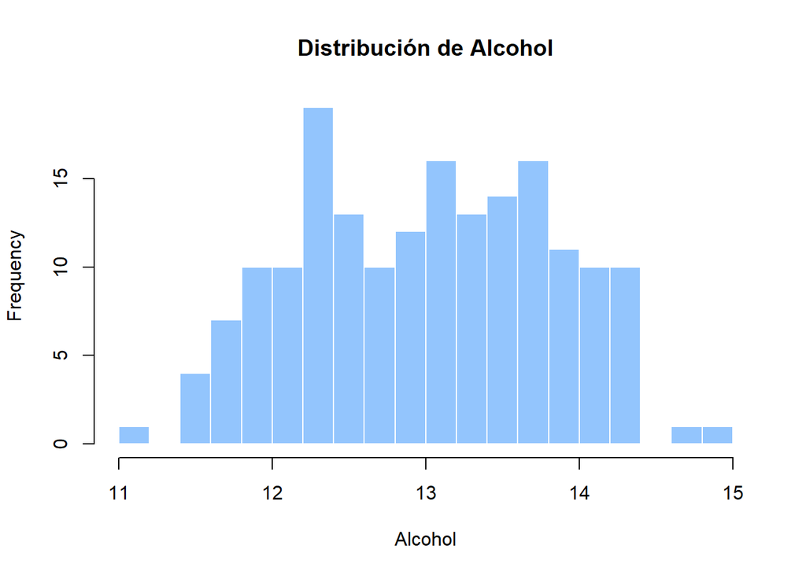

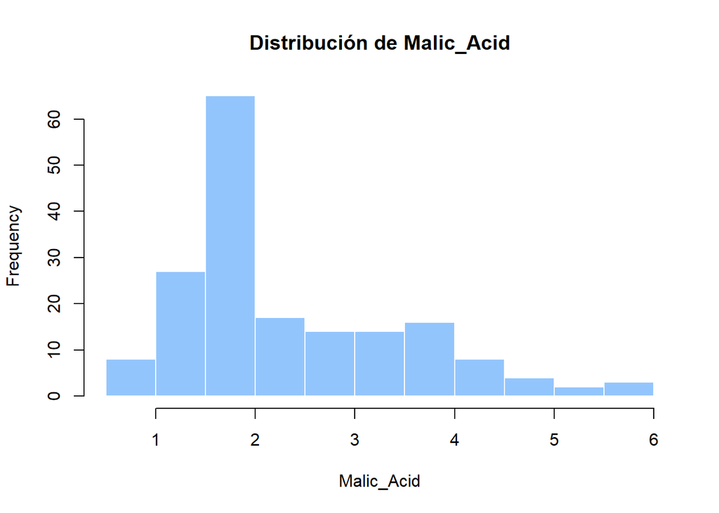

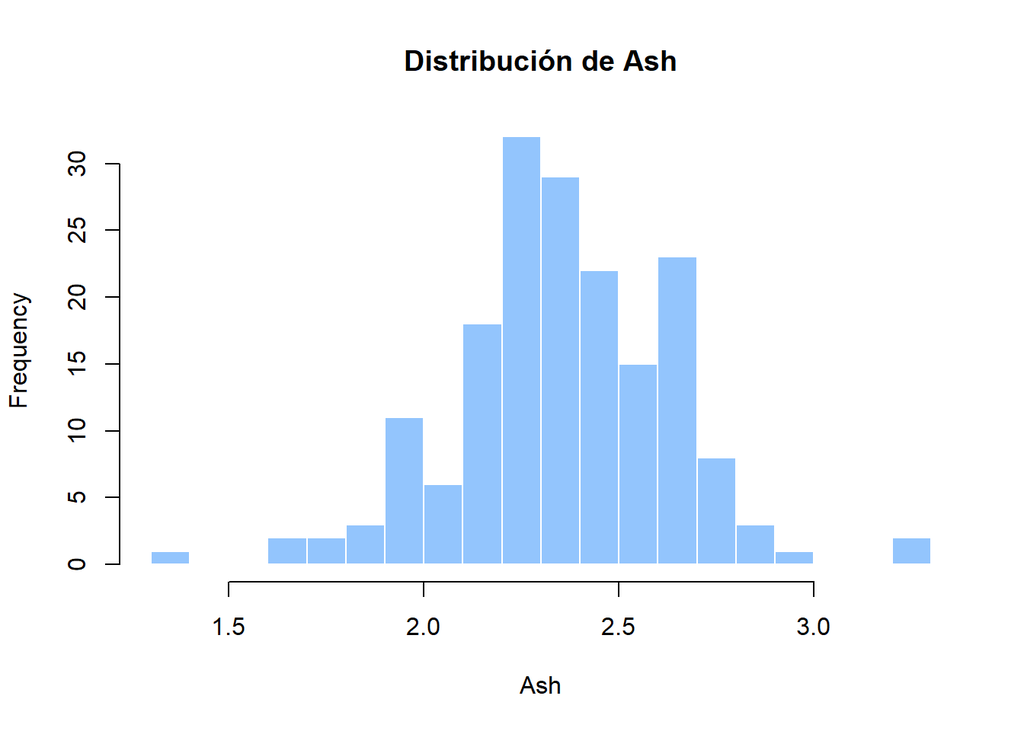

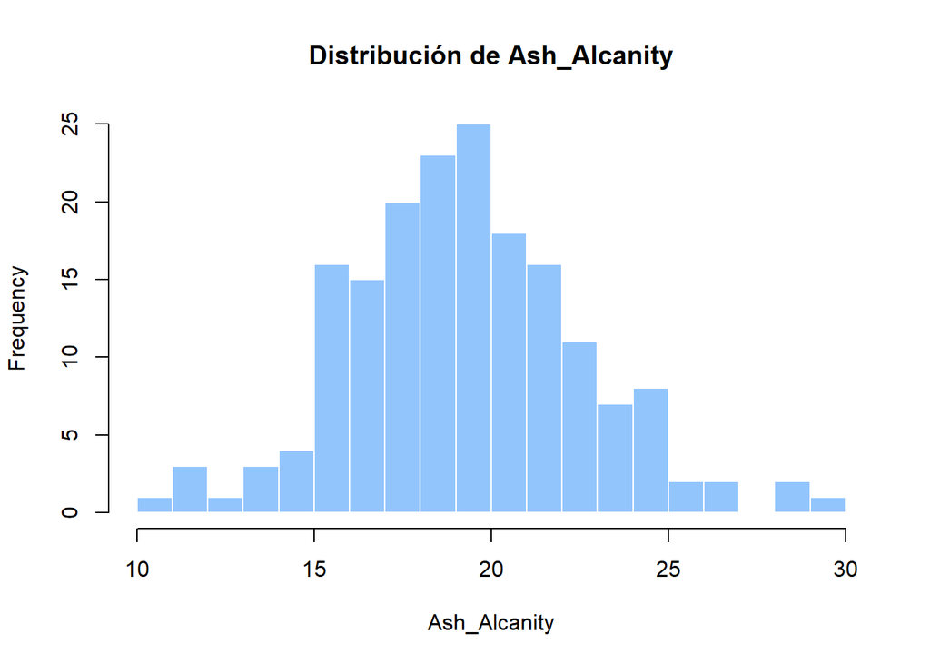

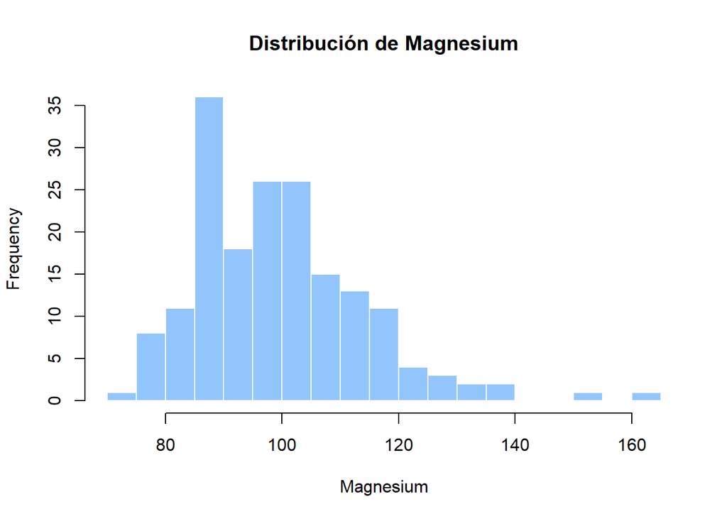

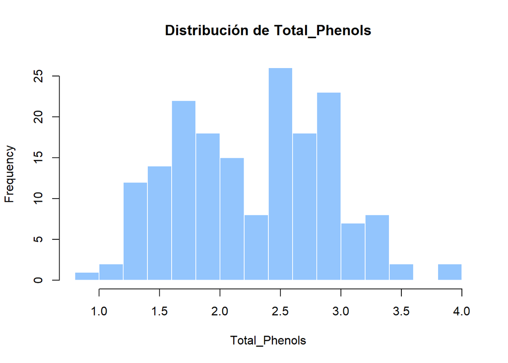

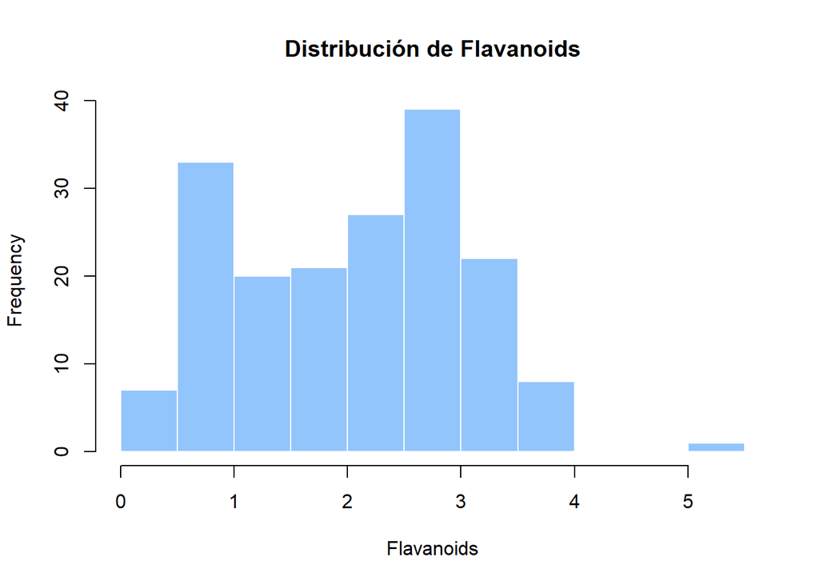

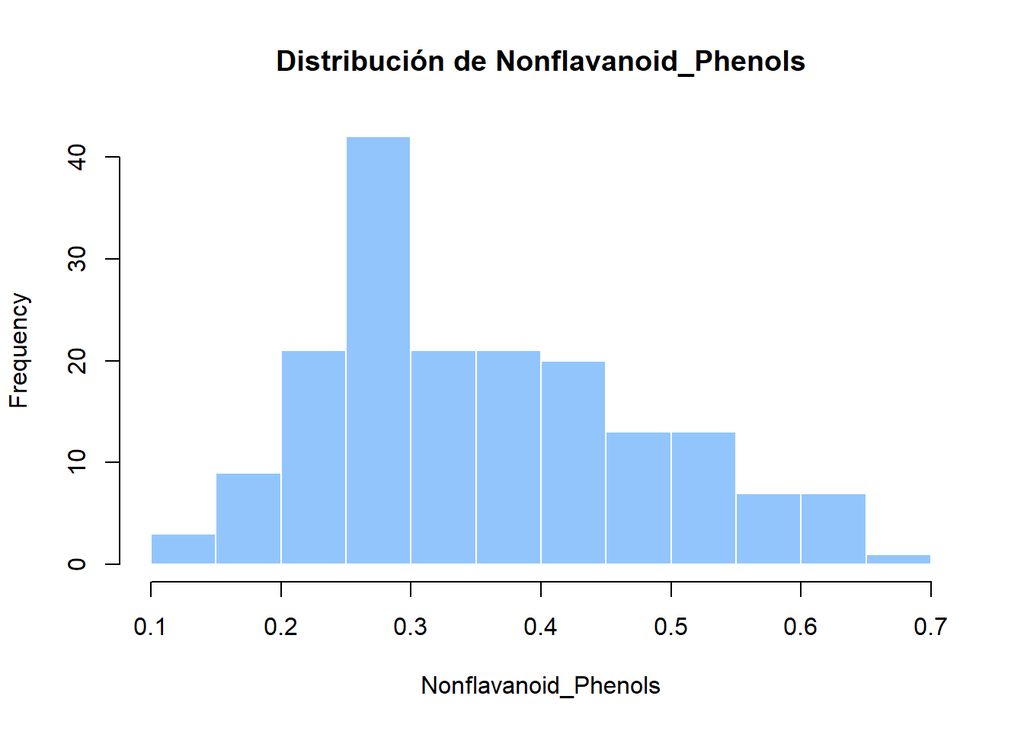

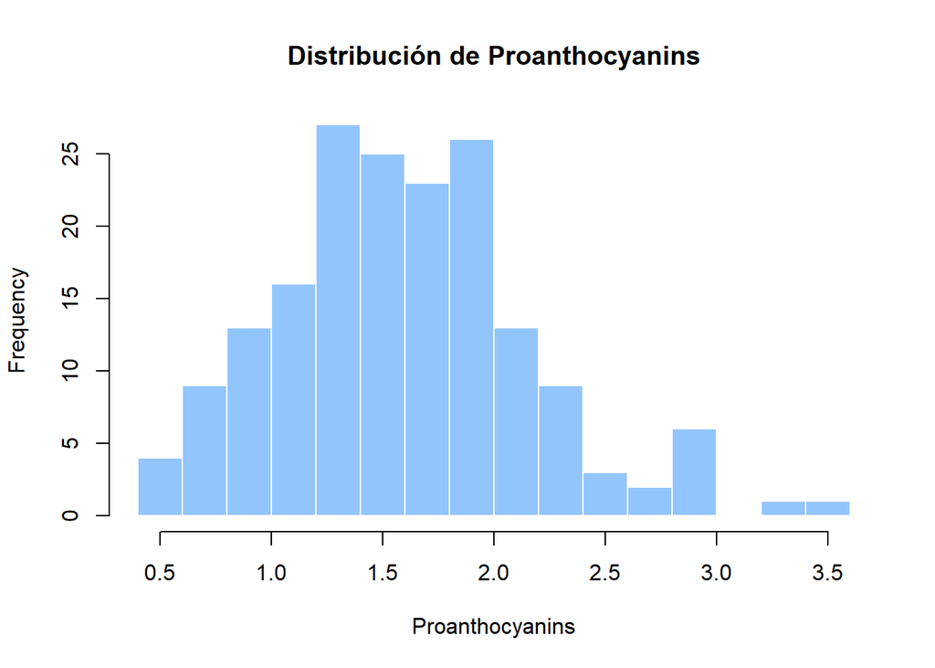

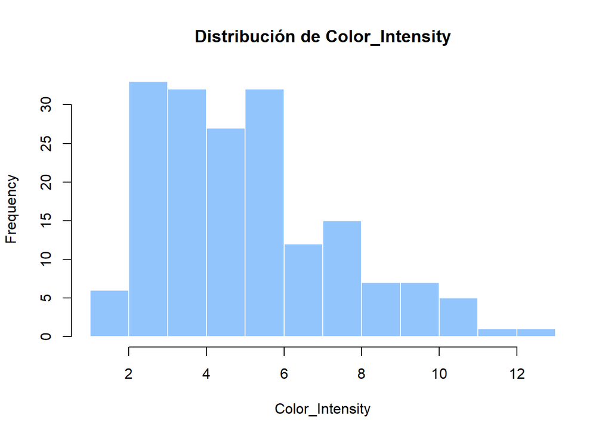

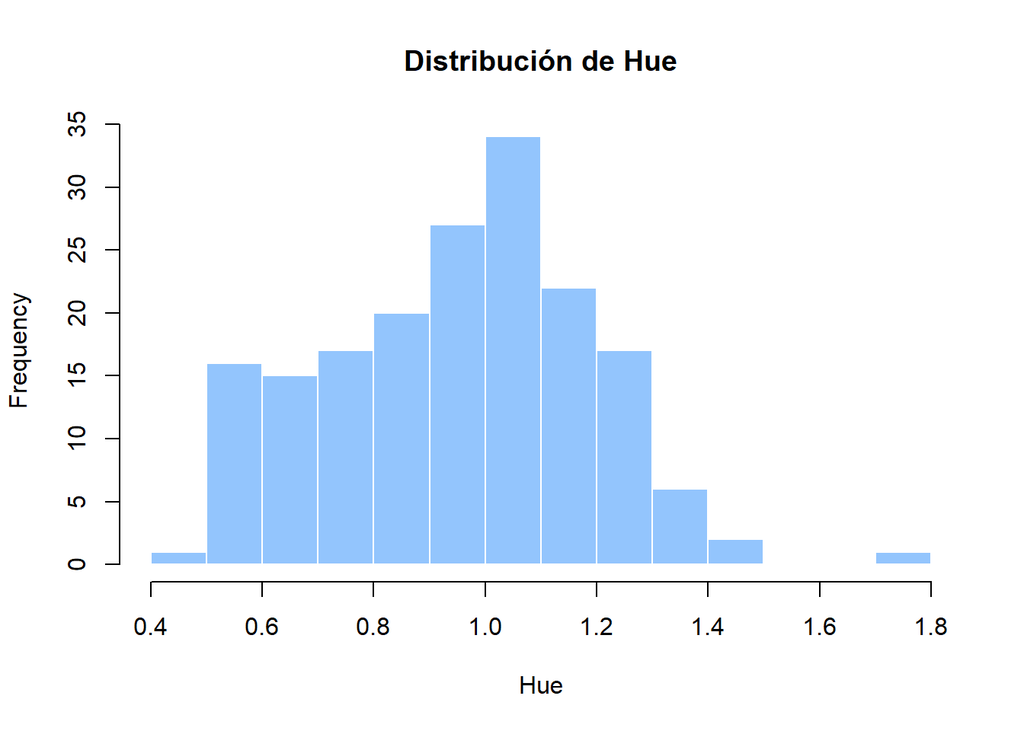

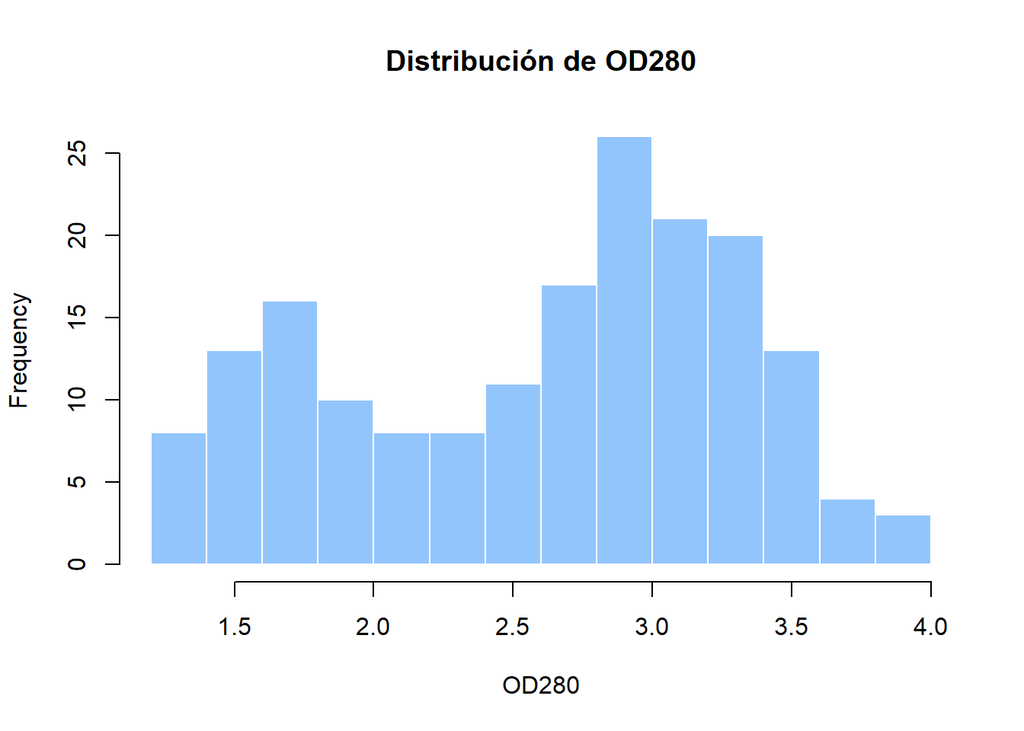

[1 more figures not shown]

```r
for (var in names(wine)) {
  hist(wine[[var]],
       main = paste("Distribución de", var),
       xlab = var,
       col = "#93c5fd",
       border = "white",
       breaks = 15)
}
```

A partir de las medias y medianas calculadas en la sección anterior, se observan diferencias notables en algunas variables que sugieren distribuciones asimétricas. **Proline** presenta una media de 746.9 y una mediana de 673.5, con una diferencia considerable que indica una distribución sesgada hacia la derecha (cola de valores altos). De forma similar, **Malic_Acid** tiene una media de 2.34 frente a una mediana de 1.87, mostrando también asimetría positiva.

En contraste, variables como **Alcohol** y **Ash** muestran medias y medianas muy cercanas entre sí, lo que sugiere distribuciones más simétricas, cercanas a una forma normal.

Estas diferencias de forma son relevantes para el modelado posterior: variables muy asimétricas pueden requerir mayor atención al estandarizar antes de aplicar K-Means, ya que los valores extremos de la cola influyen más en la distancia euclidiana.

### 6.1.2 Histogramas

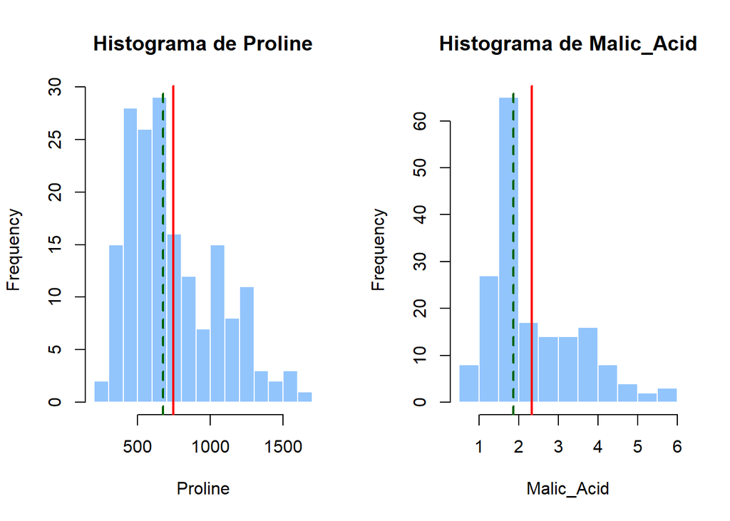

```r
par(mfrow = c(1, 2))

hist(wine$Proline,
     main = "Histograma de Proline",
     xlab = "Proline",
     col = "#93c5fd",
     border = "white",
     breaks = 15)
abline(v = mean(wine$Proline), col = "red", lwd = 2)
abline(v = median(wine$Proline), col = "darkgreen", lwd = 2, lty = 2)

hist(wine$Malic_Acid,
     main = "Histograma de Malic_Acid",
     xlab = "Malic_Acid",
     col = "#93c5fd",
     border = "white",
     breaks = 15)
abline(v = mean(wine$Malic_Acid), col = "red", lwd = 2)
abline(v = median(wine$Malic_Acid), col = "darkgreen", lwd = 2, lty = 2)
```

```r
par(mfrow = c(1, 1))
```

Los histogramas de **Proline** y **Malic_Acid** muestran claramente la cola hacia la derecha mencionada anteriormente: la línea roja (media) queda desplazada hacia la derecha respecto a la línea verde punteada (mediana), confirmando la asimetría positiva en ambas variables.

### 6.1.3 Diagramas de caja

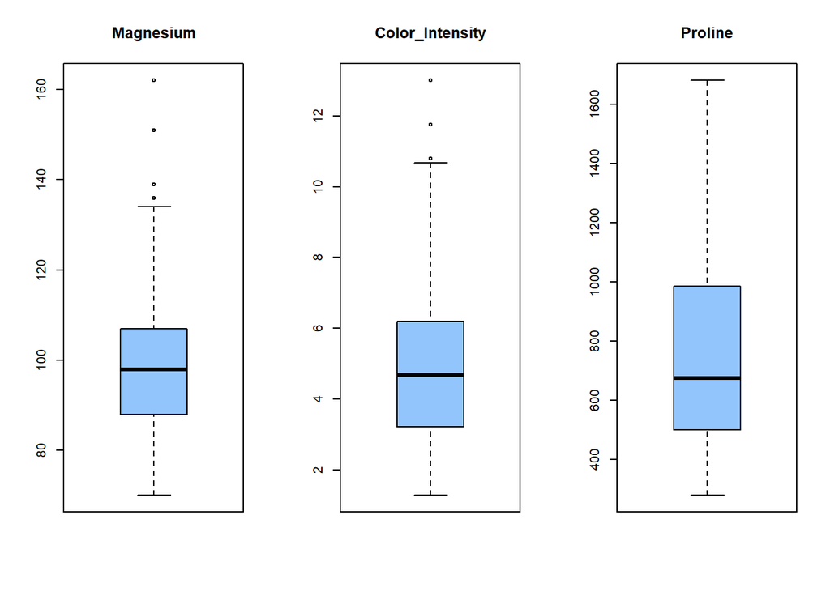

```r
# Variables con escalas grandes (decenas/cientos)
par(mfrow = c(1, 3))
boxplot(wine$Magnesium, main = "Magnesium", col = "#93c5fd")
boxplot(wine$Color_Intensity, main = "Color_Intensity", col = "#93c5fd")
boxplot(wine$Proline, main = "Proline", col = "#93c5fd")
```

```r
par(mfrow = c(1, 1))
```

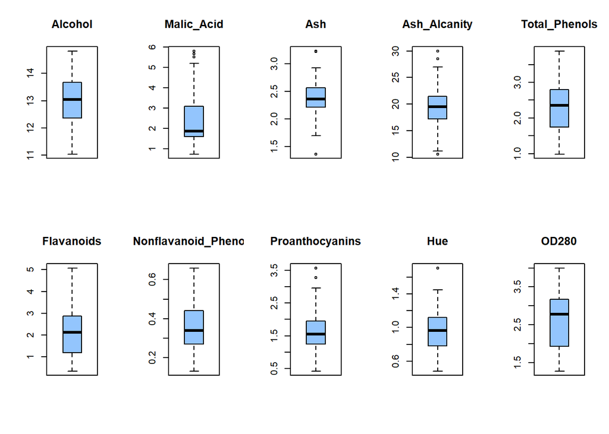

```r
# Variables con escalas pequeñas (unidades/decimales)
par(mfrow = c(2, 5))
boxplot(wine$Alcohol, main = "Alcohol", col = "#93c5fd")
boxplot(wine$Malic_Acid, main = "Malic_Acid", col = "#93c5fd")
boxplot(wine$Ash, main = "Ash", col = "#93c5fd")
boxplot(wine$Ash_Alcanity, main = "Ash_Alcanity", col = "#93c5fd")
boxplot(wine$Total_Phenols, main = "Total_Phenols", col = "#93c5fd")
boxplot(wine$Flavanoids, main = "Flavanoids", col = "#93c5fd")
boxplot(wine$Nonflavanoid_Phenols, main = "Nonflavanoid_Phenols", col = "#93c5fd")
boxplot(wine$Proanthocyanins, main = "Proanthocyanins", col = "#93c5fd")
boxplot(wine$Hue, main = "Hue", col = "#93c5fd")
boxplot(wine$OD280, main = "OD280", col = "#93c5fd")
```

```r
par(mfrow = c(1, 1))
```

Los diagramas de caja permiten visualizar directamente los posibles valores atípicos (puntos fuera de los bigotes) detectados previamente por el método IQR en la sección de análisis preexploratorio.

### 6.1.4 Valores atípicos

```r
detectar_outliers <- function(x) {
  Q1 <- quantile(x, 0.25, na.rm = TRUE)
  Q3 <- quantile(x, 0.75, na.rm = TRUE)
  IQR_valor <- Q3 - Q1
  limite_inferior <- Q1 - 1.5 * IQR_valor
  limite_superior <- Q3 + 1.5 * IQR_valor
  which(x < limite_inferior | x > limite_superior)
}

variables_con_outliers <- c("Ash_Alcanity", "Magnesium", "Color_Intensity",
                             "Malic_Acid", "Ash", "Proanthocyanins", "Hue")

for (var in variables_con_outliers) {
  filas <- detectar_outliers(wine[[var]])
  cat("Variable:", var, "- Filas atípicas:", paste(filas, collapse = ", "), "\n")
}
```

```
## Variable: Ash_Alcanity - Filas atípicas: 60, 74, 122, 128
## Variable: Magnesium - Filas atípicas: 70, 74, 79, 96
## Variable: Color_Intensity - Filas atípicas: 152, 159, 160, 167
## Variable: Malic_Acid - Filas atípicas: 124, 138, 174
## Variable: Ash - Filas atípicas: 26, 60, 122
## Variable: Proanthocyanins - Filas atípicas: 96, 111
## Variable: Hue - Filas atípicas: 116
```

Los valores atípicos identificados coinciden con los ya reportados en el análisis preexploratorio: **Ash_Alcanity, Magnesium y Color_Intensity** presentan la mayor cantidad (4 cada una), seguidas de **Malic_Acid y Ash** (3 cada una), **Proanthocyanins** (2) y **Hue** (1). Siguiendo el criterio definido por el grupo, ninguno de estos valores se elimina en esta etapa: se trata de observaciones reales dentro del rango químico esperado para distintos cultivares de vino, y su tratamiento definitivo se evaluará más adelante, en conjunto con el resto de variables, antes del modelado.

### 6.1.5 Hallazgos del análisis univariado

Sobre los valores atípicos, encontré puntos fuera de rango en 7 de las 13 variables: Ash_Alcanity, Magnesium, Color_Intensity, Malic_Acid, Ash, Proanthocyanins y Hue. Las cantidades que me dieron coinciden con las que ya se habían calculado en el análisis preexploratorio, así que todo cuadra. Revisando esos valores, no parecen errores de digitación ni nada raro, están dentro de un rango que tiene sentido para vino, así que probablemente sea variabilidad normal entre los distintos cultivares y no algo que haya que corregir.

Con esto le doy respuesta a varias de las preguntas que nos planteamos como grupo (la 1, la 2 y la 4), sobre variabilidad, comportamiento de los atípicos y asimetría. Y me parece que deja bien preparado el terreno para lo que sigue: el análisis bivariado y, más adelante, la estandarización antes de meter el modelo, porque tanto las diferencias de escala como estas asimetrías que encontré podrían afectarle a K-Means si no se manejan bien.

## 6.2 Análisis bivariado

### 6.2.1 Objetivo del análisis bivariado

El análisis bivariado estudia la relación entre pares de variables. En este proyecto se utiliza para identificar características químicas que cambian conjuntamente, relaciones positivas o negativas, asociaciones débiles y posible información redundante.

Este análisis es importante para el clustering porque permite conocer si varias variables podrían estar aportando información semejante y facilita la interpretación de los perfiles químicos presentes antes de aplicar el modelo.

### 6.2.2 Correlaciones

Debido a que todas las variables son numéricas, se calculó la correlación de Pearson. Este coeficiente toma valores entre -1 y 1. El signo indica la dirección de la relación, mientras que el valor absoluto indica su intensidad.

Para facilitar la interpretación se utilizó el siguiente criterio:

- Correlación absoluta entre 0.00 y 0.29: relación lineal débil.
- Correlación absoluta entre 0.30 y 0.59: relación lineal moderada.
- Correlación absoluta entre 0.60 y 0.79: relación lineal fuerte.
- Correlación absoluta entre 0.80 y 1.00: relación lineal muy fuerte.
- Un signo positivo indica que ambas variables tienden a cambiar en la misma dirección.
- Un signo negativo indica que las variables tienden a cambiar en direcciones opuestas.
- La correlación no implica causalidad.

Estos intervalos se utilizan como una guía descriptiva para organizar el análisis y no como límites universales o absolutos.

```r
# Calcular la matriz de correlación de Pearson
matriz_correlacion <- cor(
  wine,
  method = "pearson",
  use = "complete.obs"
)

# Mostrar la matriz redondeada
knitr::kable(
  round(matriz_correlacion, 2),
  caption = "Matriz de correlación de las características químicas",
  align = rep("c", ncol(matriz_correlacion))
)
```

Matriz de correlación de las características químicas

|  | Alcohol | Malic_Acid | Ash | Ash_Alcanity | Magnesium | Total_Phenols | Flavanoids | Nonflavanoid_Phenols | Proanthocyanins | Color_Intensity | Hue | OD280 | Proline |
| --- | --- | --- | --- | --- | --- | --- | --- | --- | --- | --- | --- | --- | --- |
| Alcohol | 1.00 | 0.09 | 0.21 | -0.31 | 0.27 | 0.29 | 0.24 | -0.16 | 0.14 | 0.55 | -0.07 | 0.07 | 0.64 |
| Malic_Acid | 0.09 | 1.00 | 0.16 | 0.29 | -0.05 | -0.34 | -0.41 | 0.29 | -0.22 | 0.25 | -0.56 | -0.37 | -0.19 |
| Ash | 0.21 | 0.16 | 1.00 | 0.44 | 0.29 | 0.13 | 0.12 | 0.19 | 0.01 | 0.26 | -0.07 | 0.00 | 0.22 |
| Ash_Alcanity | -0.31 | 0.29 | 0.44 | 1.00 | -0.08 | -0.32 | -0.35 | 0.36 | -0.20 | 0.02 | -0.27 | -0.28 | -0.44 |
| Magnesium | 0.27 | -0.05 | 0.29 | -0.08 | 1.00 | 0.21 | 0.20 | -0.26 | 0.24 | 0.20 | 0.06 | 0.07 | 0.39 |
| Total_Phenols | 0.29 | -0.34 | 0.13 | -0.32 | 0.21 | 1.00 | 0.86 | -0.45 | 0.61 | -0.06 | 0.43 | 0.70 | 0.50 |
| Flavanoids | 0.24 | -0.41 | 0.12 | -0.35 | 0.20 | 0.86 | 1.00 | -0.54 | 0.65 | -0.17 | 0.54 | 0.79 | 0.49 |
| Nonflavanoid_Phenols | -0.16 | 0.29 | 0.19 | 0.36 | -0.26 | -0.45 | -0.54 | 1.00 | -0.37 | 0.14 | -0.26 | -0.50 | -0.31 |
| Proanthocyanins | 0.14 | -0.22 | 0.01 | -0.20 | 0.24 | 0.61 | 0.65 | -0.37 | 1.00 | -0.03 | 0.30 | 0.52 | 0.33 |
| Color_Intensity | 0.55 | 0.25 | 0.26 | 0.02 | 0.20 | -0.06 | -0.17 | 0.14 | -0.03 | 1.00 | -0.52 | -0.43 | 0.32 |
| Hue | -0.07 | -0.56 | -0.07 | -0.27 | 0.06 | 0.43 | 0.54 | -0.26 | 0.30 | -0.52 | 1.00 | 0.57 | 0.24 |
| OD280 | 0.07 | -0.37 | 0.00 | -0.28 | 0.07 | 0.70 | 0.79 | -0.50 | 0.52 | -0.43 | 0.57 | 1.00 | 0.31 |
| Proline | 0.64 | -0.19 | 0.22 | -0.44 | 0.39 | 0.50 | 0.49 | -0.31 | 0.33 | 0.32 | 0.24 | 0.31 | 1.00 |

La tabla permite observar la dirección y la intensidad de las relaciones lineales entre todas las características químicas. Sin embargo, debido a la cantidad de valores, también se genera una representación gráfica para facilitar su interpretación.

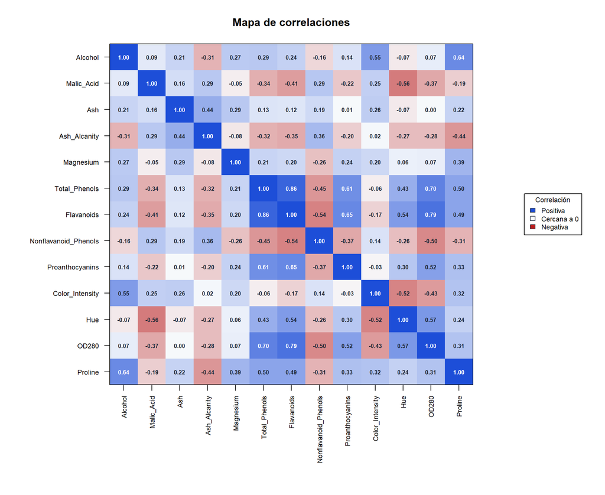

Mapa de correlaciones entre las características químicas

```r
# Guardar los márgenes gráficos originales
margenes_originales <- par("mar")

# Ajustar los márgenes para mostrar los nombres de las variables
par(mar = c(10, 10, 4, 12))

# Cantidad de variables
cantidad_variables <- ncol(matriz_correlacion)

# Crear una escala de colores
# Rojo: correlación negativa
# Blanco: correlación cercana a cero
# Azul: correlación positiva
colores_correlacion <- colorRampPalette(
  c("#b91c1c", "#f8fafc", "#1d4ed8")
)(200)

# Preparar la matriz para que aparezca en el orden correcto
matriz_grafico <- t(
  matriz_correlacion[
    cantidad_variables:1,
  ]
)

# Dibujar el mapa de correlaciones
image(
  x = seq_len(cantidad_variables),
  y = seq_len(cantidad_variables),
  z = matriz_grafico,
  col = colores_correlacion,
  zlim = c(-1, 1),
  axes = FALSE,
  xlab = "",
  ylab = "",
  main = "Mapa de correlaciones"
)

# Agregar nombres en el eje horizontal
axis(
  side = 1,
  at = seq_len(cantidad_variables),
  labels = colnames(matriz_correlacion),
  las = 2,
  cex.axis = 0.75
)

# Agregar nombres en el eje vertical
axis(
  side = 2,
  at = seq_len(cantidad_variables),
  labels = rev(rownames(matriz_correlacion)),
  las = 2,
  cex.axis = 0.75
)

# Agregar los valores de correlación dentro de las casillas
for (columna in seq_len(cantidad_variables)) {

  for (fila in seq_len(cantidad_variables)) {

    valor_correlacion <- matriz_correlacion[
      cantidad_variables + 1 - fila,
      columna
    ]

    # Usar texto blanco en casillas oscuras
    color_numero <- ifelse(
      abs(valor_correlacion) >= 0.60,
      "white",
      "#1f2937"
    )

    text(
      x = columna,
      y = fila,
      labels = sprintf("%.2f", valor_correlacion),
      col = color_numero,
      cex = 0.63,
      font = 2
    )
  }
}

# Dibujar el borde del gráfico
box()

# Agregar leyenda a la derecha, fuera de la matriz
legend(
  "right",
  inset = c(-0.30, 0),
  xpd = TRUE,
  legend = c(
    "Positiva",
    "Cercana a 0",
    "Negativa"
  ),
  fill = c(
    "#1d4ed8",
    "#f8fafc",
    "#b91c1c"
  ),
  border = "#374151",
  bg = "white",
  title = "Correlación",
  cex = 0.75,
  bty = "o"
)
```

```r
# Restaurar los márgenes originales
par(mar = margenes_originales)
```

El mapa permite observar simultáneamente la dirección, la intensidad y el valor de las correlaciones. Los tonos azules representan relaciones positivas, los tonos rojos representan relaciones negativas y los colores claros indican correlaciones cercanas a cero. La diagonal presenta valores de 1.00 porque cada variable mantiene una correlación perfecta consigo misma.

### 6.2.3 Relaciones más fuertes

Para facilitar la interpretación, se transformó la matriz en una tabla de pares y se ordenaron las relaciones según el valor absoluto de su correlación.

```r
# Obtener las posiciones de la parte superior de la matriz
posiciones_pares <- which(
  upper.tri(matriz_correlacion),
  arr.ind = TRUE
)

# Crear tabla con todos los pares
tabla_correlaciones <- data.frame(
  Variable_1 = rownames(matriz_correlacion)[posiciones_pares[, 1]],
  Variable_2 = colnames(matriz_correlacion)[posiciones_pares[, 2]],
  Correlacion = matriz_correlacion[posiciones_pares]
)

# Calcular la correlación absoluta
tabla_correlaciones$Correlacion_Absoluta <- abs(
  tabla_correlaciones$Correlacion
)

# Ordenar desde la correlación más fuerte
tabla_correlaciones <- tabla_correlaciones[
  order(
    tabla_correlaciones$Correlacion_Absoluta,
    decreasing = TRUE
  ),
]

# Seleccionar las diez relaciones más fuertes
relaciones_principales <- head(tabla_correlaciones, 10)

# Clasificar la dirección
relaciones_principales$Direccion <- ifelse(
  relaciones_principales$Correlacion > 0,
  "Positiva",
  "Negativa"
)

# Redondear para presentar los resultados
relaciones_principales$Correlacion <- round(
  relaciones_principales$Correlacion,
  3
)

# Mostrar columnas relevantes
knitr::kable(
  relaciones_principales[
    ,
    c("Variable_1", "Variable_2", "Correlacion", "Direccion")
  ],
  caption = "Diez relaciones lineales más fuertes",
  align = c("l", "l", "c", "c")
)
```

Diez relaciones lineales más fuertes

|  | Variable_1 | Variable_2 | Correlacion | Direccion |
| --- | --- | --- | --- | --- |
| 21 | Total_Phenols | Flavanoids | 0.865 | Positiva |
| 62 | Flavanoids | OD280 | 0.787 | Positiva |
| 61 | Total_Phenols | OD280 | 0.700 | Positiva |
| 35 | Flavanoids | Proanthocyanins | 0.653 | Positiva |
| 67 | Alcohol | Proline | 0.644 | Positiva |
| 34 | Total_Phenols | Proanthocyanins | 0.612 | Positiva |
| 66 | Hue | OD280 | 0.565 | Positiva |
| 47 | Malic_Acid | Hue | -0.561 | Negativa |
| 37 | Alcohol | Color_Intensity | 0.546 | Positiva |
| 52 | Flavanoids | Hue | 0.543 | Positiva |

La correlación positiva más fuerte se observa entre Total_Phenols y Flavanoids. También destacan las relaciones de Flavanoids con OD280, Total_Phenols con OD280, Flavanoids con Proanthocyanins y Alcohol con Proline.

Los resultados muestran que varias características relacionadas con los compuestos fenólicos presentan comportamientos semejantes. Esto indica que ciertas muestras de vino pueden compartir perfiles químicos donde los fenoles totales, los flavonoides y OD280 aumentan de manera conjunta.

### 6.2.4 Gráficos de dispersión

Los gráficos de dispersión permiten verificar visualmente las relaciones encontradas mediante la correlación. Cada punto representa una muestra de vino y la línea superpuesta representa la tendencia lineal general entre las dos variables.

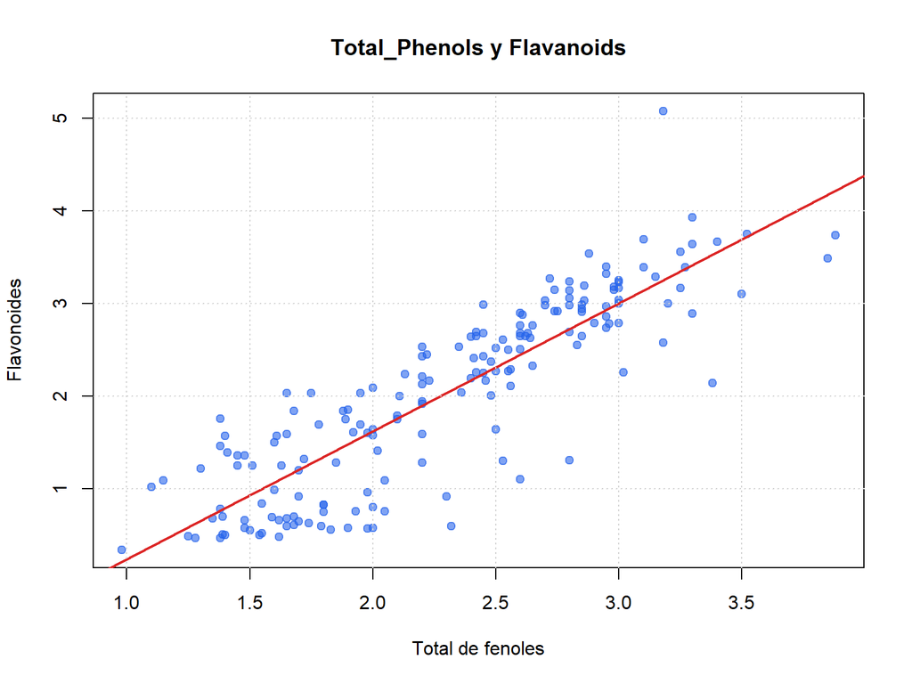

Relación entre Total_Phenols y Flavanoids

```r
plot(
  wine$Total_Phenols,
  wine$Flavanoids,
  pch = 19,
  col = rgb(37, 99, 235, 150, maxColorValue = 255),
  xlab = "Total de fenoles",
  ylab = "Flavonoides",
  main = "Total_Phenols y Flavanoids"
)

abline(
  lm(Flavanoids ~ Total_Phenols, data = wine),
  col = "#dc2626",
  lwd = 2
)

grid()
```

```r
cor_fenoles_flavanoides <- cor(
  wine$Total_Phenols,
  wine$Flavanoids
)

cat(
  "Correlación entre Total_Phenols y Flavanoids:",
  round(cor_fenoles_flavanoides, 3)
)
```

```
## Correlación entre Total_Phenols y Flavanoids: 0.865
```

La nube de puntos presenta una dirección ascendente clara. Esto indica que las muestras con valores altos de Total_Phenols tienden también a presentar valores altos de Flavanoids. El resultado coincide con la correlación positiva muy fuerte encontrada entre ambas variables.

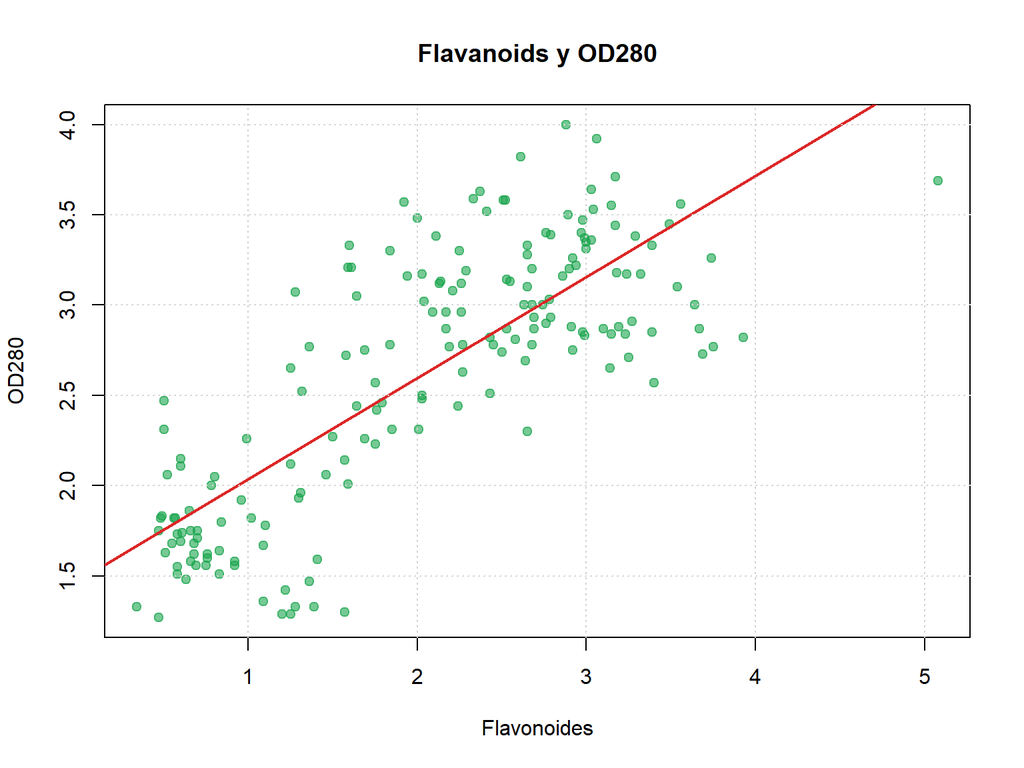

Relación entre Flavanoids y OD280

```r
plot(
  wine$Flavanoids,
  wine$OD280,
  pch = 19,
  col = rgb(22, 163, 74, 150, maxColorValue = 255),
  xlab = "Flavonoides",
  ylab = "OD280",
  main = "Flavanoids y OD280"
)

abline(
  lm(OD280 ~ Flavanoids, data = wine),
  col = "#dc2626",
  lwd = 2
)

grid()
```

```r
cor_flavanoides_od280 <- cor(
  wine$Flavanoids,
  wine$OD280
)

cat(
  "Correlación entre Flavanoids y OD280:",
  round(cor_flavanoides_od280, 3)
)
```

```
## Correlación entre Flavanoids y OD280: 0.787
```

La relación entre Flavanoids y OD280 también es positiva y fuerte. Las muestras con mayores concentraciones de flavonoides tienden a presentar valores elevados de OD280, aunque existe más dispersión que en la relación entre Total_Phenols y Flavanoids.

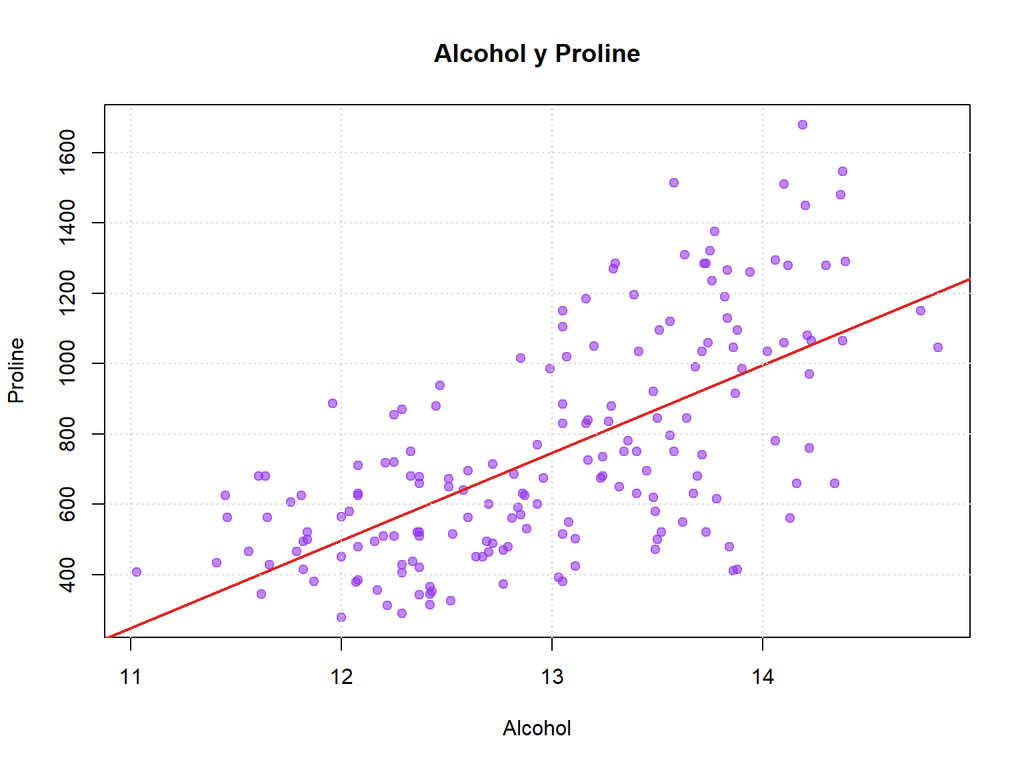

Relación entre Alcohol y Proline

```r
plot(
  wine$Alcohol,
  wine$Proline,
  pch = 19,
  col = rgb(147, 51, 234, 150, maxColorValue = 255),
  xlab = "Alcohol",
  ylab = "Proline",
  main = "Alcohol y Proline"
)

abline(
  lm(Proline ~ Alcohol, data = wine),
  col = "#dc2626",
  lwd = 2
)

grid()
```

```r
cor_alcohol_proline <- cor(
  wine$Alcohol,
  wine$Proline
)

cat(
  "Correlación entre Alcohol y Proline:",
  round(cor_alcohol_proline, 3)
)
```

```
## Correlación entre Alcohol y Proline: 0.644
```

Alcohol y Proline presentan una relación positiva fuerte. Aunque existe dispersión entre las observaciones, se aprecia una tendencia donde las muestras con concentraciones mayores de alcohol también tienden a presentar valores mayores de Proline.

### 6.2.5 Relaciones negativas

Una correlación negativa indica que, en términos generales, una variable tiende a disminuir cuando la otra aumenta.

```r
# Seleccionar únicamente correlaciones negativas
relaciones_negativas <- tabla_correlaciones[
  tabla_correlaciones$Correlacion < 0,
]

# Ordenar según la intensidad absoluta
relaciones_negativas <- relaciones_negativas[
  order(
    relaciones_negativas$Correlacion_Absoluta,
    decreasing = TRUE
  ),
]

# Seleccionar las cinco relaciones negativas más fuertes
principales_negativas <- head(relaciones_negativas, 5)

principales_negativas$Correlacion <- round(
  principales_negativas$Correlacion,
  3
)

knitr::kable(
  principales_negativas[
    ,
    c("Variable_1", "Variable_2", "Correlacion")
  ],
  caption = "Cinco relaciones negativas más fuertes",
  align = c("l", "l", "c")
)
```

Cinco relaciones negativas más fuertes

|  | Variable_1 | Variable_2 | Correlacion |
| --- | --- | --- | --- |
| 47 | Malic_Acid | Hue | -0.561 |
| 28 | Flavanoids | Nonflavanoid_Phenols | -0.538 |
| 55 | Color_Intensity | Hue | -0.522 |
| 63 | Nonflavanoid_Phenols | OD280 | -0.503 |
| 27 | Total_Phenols | Nonflavanoid_Phenols | -0.450 |

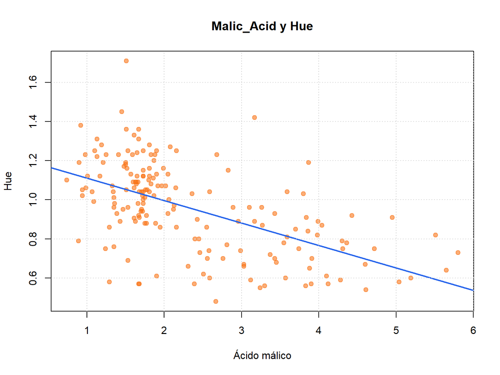

Relación entre Malic_Acid y Hue

```r
plot(
  wine$Malic_Acid,
  wine$Hue,
  pch = 19,
  col = rgb(249, 115, 22, 150, maxColorValue = 255),
  xlab = "Ácido málico",
  ylab = "Hue",
  main = "Malic_Acid y Hue"
)

abline(
  lm(Hue ~ Malic_Acid, data = wine),
  col = "#2563eb",
  lwd = 2
)

grid()
```

```r
cor_malic_hue <- cor(
  wine$Malic_Acid,
  wine$Hue
)

cat(
  "Correlación entre Malic_Acid y Hue:",
  round(cor_malic_hue, 3)
)
```

```
## Correlación entre Malic_Acid y Hue: -0.561
```

Malic_Acid y Hue presentan una relación negativa moderada. Esto significa que las muestras con valores altos de ácido málico tienden, en general, a presentar valores menores de Hue. La dispersión observada indica que la relación no es perfecta y que Hue también puede estar asociado con otras características.

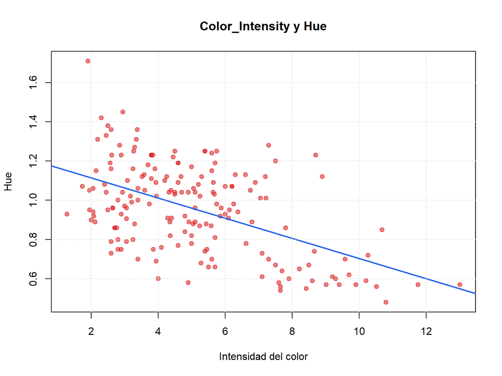

Relación entre Color_Intensity y Hue

```r
plot(
  wine$Color_Intensity,
  wine$Hue,
  pch = 19,
  col = rgb(220, 38, 38, 150, maxColorValue = 255),
  xlab = "Intensidad del color",
  ylab = "Hue",
  main = "Color_Intensity y Hue"
)

abline(
  lm(Hue ~ Color_Intensity, data = wine),
  col = "#2563eb",
  lwd = 2
)

grid()
```

```r
cor_color_hue <- cor(
  wine$Color_Intensity,
  wine$Hue
)

cat(
  "Correlación entre Color_Intensity y Hue:",
  round(cor_color_hue, 3)
)
```

```
## Correlación entre Color_Intensity y Hue: -0.522
```

Color_Intensity y Hue presentan una asociación negativa moderada. Las muestras con mayor intensidad del color tienden a presentar valores menores de Hue. Esta relación puede aportar información para diferenciar perfiles de vino, ya que ambas variables muestran un comportamiento lineal inverso.

### 6.2.6 Relaciones débiles

Una correlación cercana a cero indica que no existe una relación lineal clara. Sin embargo, esto no significa que las variables sean inútiles para clustering, porque podrían contribuir de manera individual o mantener relaciones no lineales con otras características.

```r
# Ordenar las relaciones desde la correlación absoluta más baja
relaciones_debiles <- tabla_correlaciones[
  order(tabla_correlaciones$Correlacion_Absoluta),
]

# Seleccionar las cinco relaciones más débiles
relaciones_mas_debiles <- head(relaciones_debiles, 5)

relaciones_mas_debiles$Correlacion <- round(
  relaciones_mas_debiles$Correlacion,
  3
)

knitr::kable(
  relaciones_mas_debiles[
    ,
    c("Variable_1", "Variable_2", "Correlacion")
  ],
  caption = "Cinco relaciones lineales más débiles",
  align = c("l", "l", "c")
)
```

Cinco relaciones lineales más débiles

|  | Variable_1 | Variable_2 | Correlacion |
| --- | --- | --- | --- |
| 58 | Ash | OD280 | 0.004 |
| 31 | Ash | Proanthocyanins | 0.010 |
| 40 | Ash_Alcanity | Color_Intensity | 0.019 |
| 45 | Proanthocyanins | Color_Intensity | -0.025 |
| 8 | Malic_Acid | Magnesium | -0.055 |

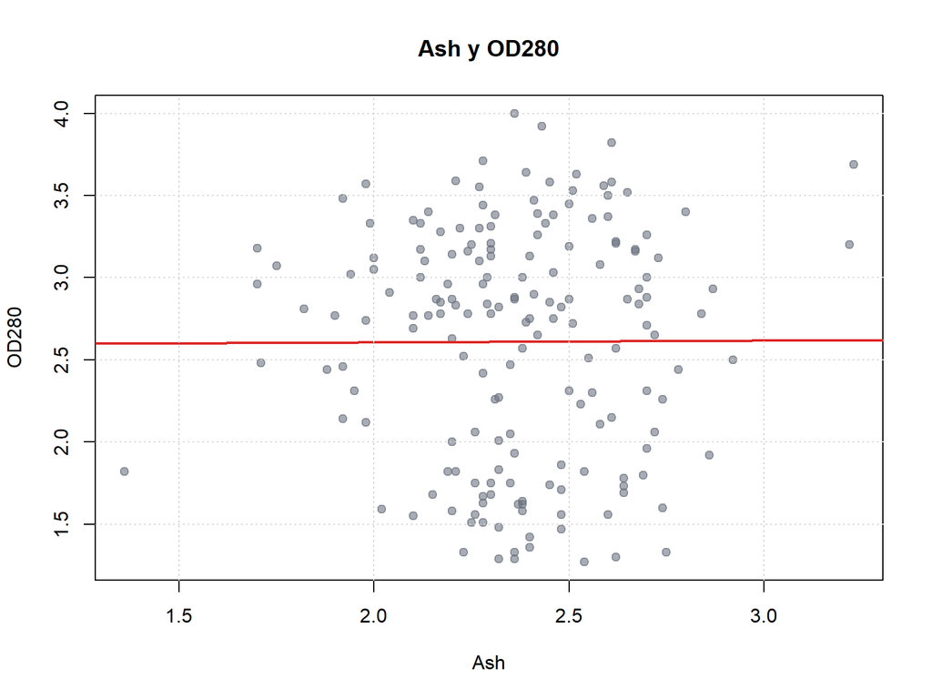

Ejemplo de relación lineal débil entre Ash y OD280

```r
plot(
  wine$Ash,
  wine$OD280,
  pch = 19,
  col = rgb(107, 114, 128, 150, maxColorValue = 255),
  xlab = "Ash",
  ylab = "OD280",
  main = "Ash y OD280"
)

abline(
  lm(OD280 ~ Ash, data = wine),
  col = "#dc2626",
  lwd = 2
)

grid()
```

```r
cor_ash_od280 <- cor(
  wine$Ash,
  wine$OD280
)

cat(
  "Correlación entre Ash y OD280:",
  round(cor_ash_od280, 3)
)
```

```
## Correlación entre Ash y OD280: 0.004
```

La relación entre Ash y OD280 es prácticamente nula. La nube de puntos no presenta una dirección ascendente o descendente definida. Esto indica que conocer el valor de Ash no permite anticipar linealmente el comportamiento de OD280.

Una correlación débil no constituye una razón suficiente para eliminar una variable. Una característica puede tener poca relación lineal con otra y aun así aportar información importante para establecer distancias y diferenciar los futuros clusters.

### 6.2.7 Variables redundantes

El análisis identificó un grupo de variables con asociaciones importantes:

- `Total_Phenols`
- `Flavanoids`
- `OD280`
- `Proanthocyanins`

La relación más elevada ocurre entre `Total_Phenols` y `Flavanoids`. Sin embargo, no se encontró ninguna correlación perfecta o prácticamente igual a 1 que demuestre que dos variables contienen exactamente la misma información.

```r
# Identificar relaciones con correlación absoluta igual o superior a 0.80
posible_redundancia <- tabla_correlaciones[
  tabla_correlaciones$Correlacion_Absoluta >= 0.80,
  c(
    "Variable_1",
    "Variable_2",
    "Correlacion",
    "Correlacion_Absoluta"
  )
]

posible_redundancia$Correlacion <- round(
  posible_redundancia$Correlacion,
  3
)

posible_redundancia$Correlacion_Absoluta <- round(
  posible_redundancia$Correlacion_Absoluta,
  3
)

knitr::kable(
  posible_redundancia,
  caption = "Pares que requieren revisión por posible redundancia",
  align = c("l", "l", "c", "c")
)
```

Pares que requieren revisión por posible redundancia

|  | Variable_1 | Variable_2 | Correlacion | Correlacion_Absoluta |
| --- | --- | --- | --- | --- |
| 21 | Total_Phenols | Flavanoids | 0.865 | 0.865 |

Existe información compartida entre Total_Phenols y Flavanoids, pero no se considera suficiente para eliminar alguna de estas variables. Se recomienda conservarlas y permitir que el PCA evalúe posteriormente su aporte conjunto.

### 6.2.8 Hallazgos del análisis bivariado

El análisis bivariado permitió identificar los siguientes hallazgos:

1. La relación lineal más fuerte se presenta entre `Total_Phenols` y `Flavanoids`, con una correlación positiva aproximada de 0.865.
2. `Flavanoids` también presenta una relación positiva fuerte con `OD280`, mientras que `Total_Phenols` mantiene una asociación importante con esa misma variable.
3. `Alcohol` y `Proline` presentan una relación positiva moderadamente fuerte, lo que sugiere un comportamiento conjunto que puede contribuir a diferenciar perfiles de vino.
4. Entre las relaciones negativas destacan `Malic_Acid` con `Hue`, `Flavanoids` con `Nonflavanoid_Phenols` y `Color_Intensity` con `Hue`.
5. También existen pares con correlación prácticamente nula, como `Ash` y `OD280`. Esto demuestra que no todas las características presentan relaciones lineales claras.
6. No se encontraron correlaciones perfectas que justifiquen eliminar automáticamente una variable.
7. Las relaciones encontradas indican que algunas características aportan información compartida, especialmente las relacionadas con los compuestos fenólicos. Sin embargo, cada variable puede conservar información útil para la identificación de perfiles químicos.
8. Se propone conservar las 13 variables y permitir que las siguientes etapas, especialmente la estandarización y el PCA, evalúen su comportamiento conjunto.

El EDA bivariado muestra que existen relaciones químicas suficientemente claras para apoyar la búsqueda de perfiles diferentes entre los vinos. Al mismo tiempo, no existe evidencia suficiente para eliminar variables antes de aplicar el análisis multivariado.

# 7 Preparación para el modelado

## 7.1 Variables finales

Después del análisis exploratorio y de la revisión de posibles relaciones redundantes, se decidió conservar las 13 variables químicas originales. No se encontraron variables constantes, problemas de calidad ni evidencia suficiente para eliminar alguna característica antes del modelado.

```r
variables_finales <- names(wine)[sapply(wine, is.numeric)]

cat("Variables finales seleccionadas:", length(variables_finales), "\n")
```

```
## Variables finales seleccionadas: 13
```

```r
cat("Variables:", paste(variables_finales, collapse = ", "), "\n")
```

```
## Variables: Alcohol, Malic_Acid, Ash, Ash_Alcanity, Magnesium, Total_Phenols, Flavanoids, Nonflavanoid_Phenols, Proanthocyanins, Color_Intensity, Hue, OD280, Proline
```

## 7.2 Estandarización

Antes de aplicar PCA y K-Means se estandarizaron las variables para que todas trabajaran en una escala comparable.

```r
wine_estandarizado <- scale(
  wine[, variables_finales]
)
```

## 7.3 Verificación de la estandarización

```r
cat("Medias después de estandarizar:\n")
```

```
## Medias después de estandarizar:
```

```r
print(round(colMeans(wine_estandarizado), 10))
```

```
##              Alcohol           Malic_Acid                  Ash
##                    0                    0                    0
##         Ash_Alcanity            Magnesium        Total_Phenols
##                    0                    0                    0
##           Flavanoids Nonflavanoid_Phenols      Proanthocyanins
##                    0                    0                    0
##      Color_Intensity                  Hue                OD280
##                    0                    0                    0
##              Proline
##                    0
```

```r
cat("\nDesviaciones estándar después de estandarizar:\n")
```

```
##
## Desviaciones estándar después de estandarizar:
```

```r
print(round(apply(wine_estandarizado, 2, sd), 10))
```

```
##              Alcohol           Malic_Acid                  Ash
##                    1                    1                    1
##         Ash_Alcanity            Magnesium        Total_Phenols
##                    1                    1                    1
##           Flavanoids Nonflavanoid_Phenols      Proanthocyanins
##                    1                    1                    1
##      Color_Intensity                  Hue                OD280
##                    1                    1                    1
##              Proline
##                    1
```

## 7.4 Justificación de la estandarización

La estandarización es necesaria porque las variables del dataset presentan escalas muy diferentes. Por ejemplo, `Proline` trabaja con valores de cientos, mientras que variables como `Hue` y `Nonflavanoid_Phenols` presentan valores mucho menores.

Esta diferencia es especialmente importante para K-Means, ya que el algoritmo utiliza distancias para formar los grupos. Si se utilizaran directamente los valores originales, las variables con magnitudes numéricas mayores podrían tener una influencia desproporcionada en el resultado.

Después de la estandarización, cada variable presenta aproximadamente una media de 0 y una desviación estándar de 1. De esta forma, todas las características químicas pueden participar en condiciones comparables.

A partir de estos datos estandarizados se evaluarán dos enfoques:

**K-Means utilizando las 13 variables estandarizadas** y **K-Means utilizando una cantidad reducida de componentes obtenidos mediante PCA**.

# 8 Análisis de Componentes Principales (PCA)

## 8.1 Objetivo del PCA

El Análisis de Componentes Principales se utiliza para determinar si la información contenida en las 13 variables químicas puede representarse mediante una cantidad menor de dimensiones.

PCA transforma las variables originales en nuevos componentes que concentran progresivamente la variabilidad presente en los datos. Los primeros componentes contienen la mayor cantidad de información, mientras que los últimos aportan cantidades cada vez menores.

Además de facilitar la visualización, en este proyecto PCA será utilizado para construir una segunda representación de los datos y posteriormente comparar un modelo K-Means basado en las variables estandarizadas contra otro basado en los componentes principales seleccionados.

## 8.2 Aplicación del PCA

Como las variables ya fueron estandarizadas previamente, no es necesario volver a escalarlas dentro de `prcomp()`.

```r
pca_resultado <- prcomp(
  wine_estandarizado,
  center = FALSE,
  scale. = FALSE
)
```

## 8.3 Varianza explicada y acumulada

La varianza explicada indica qué porcentaje de la información del dataset representa cada componente principal.

La varianza acumulada muestra cuánto de la información total se conserva al utilizar conjuntamente los primeros componentes.

```r
varianza_explicada <- (
  pca_resultado$sdev^2 /
  sum(pca_resultado$sdev^2)
)

varianza_acumulada <- cumsum(
  varianza_explicada
)

tabla_varianza <- data.frame(
  Componente = paste0(
    "PC",
    seq_along(varianza_explicada)
  ),
  Varianza_Explicada = round(
    varianza_explicada * 100,
    2
  ),
  Varianza_Acumulada = round(
    varianza_acumulada * 100,
    2
  )
)

knitr::kable(
  tabla_varianza,
  caption = "Varianza explicada y acumulada por componente principal",
  align = c("c", "c", "c")
)
```

Varianza explicada y acumulada por componente principal

| Componente | Varianza_Explicada | Varianza_Acumulada |
| --- | --- | --- |
| PC1 | 36.20 | 36.20 |
| PC2 | 19.21 | 55.41 |
| PC3 | 11.12 | 66.53 |
| PC4 | 7.07 | 73.60 |
| PC5 | 6.56 | 80.16 |
| PC6 | 4.94 | 85.10 |
| PC7 | 4.24 | 89.34 |
| PC8 | 2.68 | 92.02 |
| PC9 | 2.22 | 94.24 |
| PC10 | 1.93 | 96.17 |
| PC11 | 1.74 | 97.91 |
| PC12 | 1.30 | 99.20 |
| PC13 | 0.80 | 100.00 |

## 8.4 Selección del número de componentes

Para seleccionar la cantidad de componentes se estableció como referencia conservar al menos el **85% de la varianza acumulada**.

Este porcentaje permite mantener una parte importante de la información original y, al mismo tiempo, reducir la cantidad de dimensiones utilizadas en el segundo modelo de clustering.

```r
umbral_varianza <- 0.85

cantidad_componentes <- which(
  varianza_acumulada >= umbral_varianza
)[1]

varianza_conservada <- varianza_acumulada[
  cantidad_componentes
]

cat(
  "Umbral seleccionado:",
  umbral_varianza * 100,
  "%\n"
)
```

```
## Umbral seleccionado: 85 %
```

```r
cat(
  "Cantidad de componentes necesarios:",
  cantidad_componentes,
  "\n"
)
```

```
## Cantidad de componentes necesarios: 6
```

```r
cat(
  "Varianza acumulada conservada:",
  round(varianza_conservada * 100, 2),
  "%\n"
)
```

```
## Varianza acumulada conservada: 85.1 %
```

```r
cat(
  "Reducción de dimensiones:",
  length(variables_finales),
  "variables originales a",
  cantidad_componentes,
  "componentes principales.\n"
)
```

```
## Reducción de dimensiones: 13 variables originales a 6 componentes principales.
```

Se seleccionaron los primeros **6 componentes principales**, ya que con ellos se conserva aproximadamente el **85.1% de la varianza total**.

La decisión no se basa en escoger arbitrariamente PC1 y PC2. Esos dos componentes se utilizarán principalmente para visualización, mientras que el modelo PCA + K-Means utilizará los **6 componentes necesarios para superar el 85% de varianza acumulada**.

## 8.5 Gráfico de varianza explicada

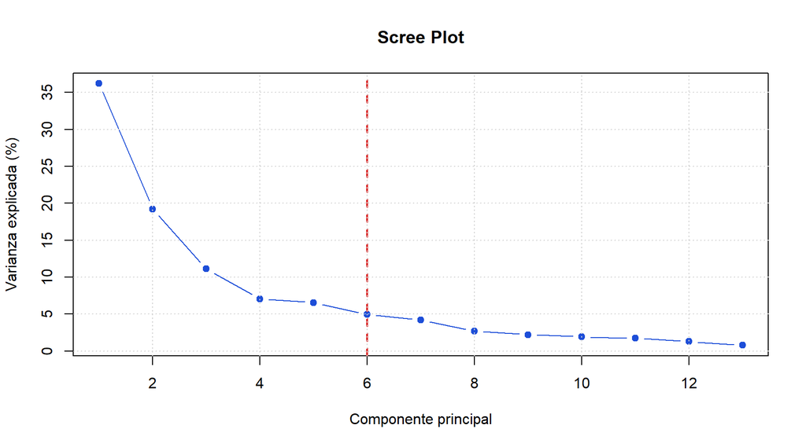

```r
plot(
  seq_along(varianza_explicada),
  varianza_explicada * 100,
  type = "b",
  pch = 19,
  col = "#1d4ed8",
  xlab = "Componente principal",
  ylab = "Varianza explicada (%)",
  main = "Scree Plot"
)

abline(
  v = cantidad_componentes,
  col = "#dc2626",
  lty = 2,
  lwd = 2
)

grid()
```

## 8.6 Gráfico de varianza acumulada

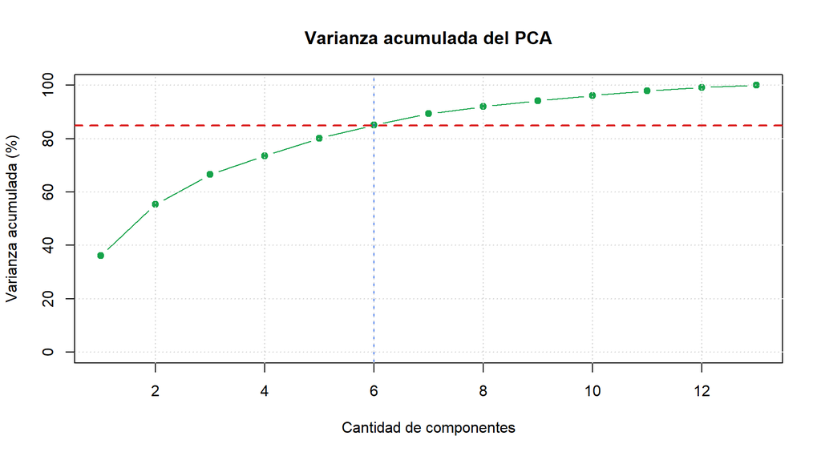

```r
plot(
  seq_along(varianza_acumulada),
  varianza_acumulada * 100,
  type = "b",
  pch = 19,
  col = "#16a34a",
  xlab = "Cantidad de componentes",
  ylab = "Varianza acumulada (%)",
  main = "Varianza acumulada del PCA",
  ylim = c(0, 100)
)

abline(
  h = umbral_varianza * 100,
  col = "#dc2626",
  lty = 2,
  lwd = 2
)

abline(
  v = cantidad_componentes,
  col = "#2563eb",
  lty = 2
)

grid()
```

## 8.7 Variables con mayor aporte a los componentes

Las cargas del PCA permiten identificar qué variables tienen mayor influencia en cada componente.

```r
cargas_pca <- pca_resultado$rotation[
  ,
  seq_len(cantidad_componentes),
  drop = FALSE
]

tabla_aportes <- do.call(
  rbind,
  lapply(
    seq_len(cantidad_componentes),
    function(i) {

      cargas <- pca_resultado$rotation[, i]

      posiciones <- order(
        abs(cargas),
        decreasing = TRUE
      )[1:3]

      data.frame(
        Componente = paste0("PC", i),
        Variable = names(cargas)[posiciones],
        Carga = round(cargas[posiciones], 3),
        Aporte_Absoluto = round(
          abs(cargas[posiciones]),
          3
        )
      )
    }
  )
)

knitr::kable(
  tabla_aportes,
  caption = "Variables con mayor aporte en los componentes seleccionados",
  align = c("c", "l", "c", "c")
)
```

Variables con mayor aporte en los componentes seleccionados

|  | Componente | Variable | Carga | Aporte_Absoluto |
| --- | --- | --- | --- | --- |
| Flavanoids | PC1 | Flavanoids | -0.423 | 0.423 |
| Total_Phenols | PC1 | Total_Phenols | -0.395 | 0.395 |
| OD280 | PC1 | OD280 | -0.376 | 0.376 |
| Color_Intensity | PC2 | Color_Intensity | -0.530 | 0.530 |
| Alcohol | PC2 | Alcohol | -0.484 | 0.484 |
| Proline | PC2 | Proline | -0.365 | 0.365 |
| Ash | PC3 | Ash | 0.626 | 0.626 |
| Ash_Alcanity | PC3 | Ash_Alcanity | 0.612 | 0.612 |
| Alcohol1 | PC3 | Alcohol | -0.207 | 0.207 |
| Malic_Acid | PC4 | Malic_Acid | 0.537 | 0.537 |
| Hue | PC4 | Hue | -0.428 | 0.428 |
| Proanthocyanins | PC4 | Proanthocyanins | 0.399 | 0.399 |
| Magnesium | PC5 | Magnesium | -0.727 | 0.727 |
| Nonflavanoid_Phenols | PC5 | Nonflavanoid_Phenols | 0.501 | 0.501 |
| Alcohol2 | PC5 | Alcohol | 0.266 | 0.266 |
| Malic_Acid1 | PC6 | Malic_Acid | -0.537 | 0.537 |
| Proanthocyanins1 | PC6 | Proanthocyanins | 0.534 | 0.534 |
| Color_Intensity1 | PC6 | Color_Intensity | 0.419 | 0.419 |

```r
top_pc1 <- names(
  sort(
    abs(pca_resultado$rotation[, 1]),
    decreasing = TRUE
  )
)[1:5]

top_pc2 <- names(
  sort(
    abs(pca_resultado$rotation[, 2]),
    decreasing = TRUE
  )
)[1:5]
```

## 8.8 Visualización de las muestras mediante PCA

Aunque para el modelado se conservarán 6 componentes, los dos primeros permiten representar visualmente la estructura principal de las muestras en un gráfico bidimensional.

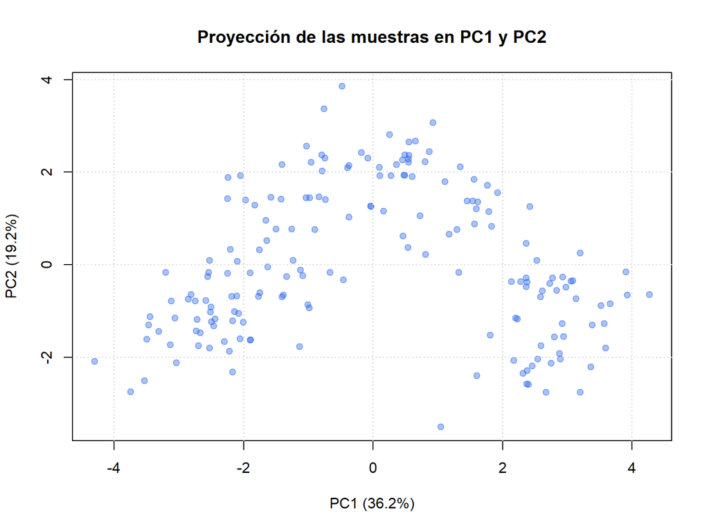

```r
pca_datos <- as.data.frame(
  pca_resultado$x
)

plot(
  pca_datos$PC1,
  pca_datos$PC2,
  pch = 19,
  col = rgb(
    37,
    99,
    235,
    100,
    maxColorValue = 255
  ),
  xlab = paste0(
    "PC1 (",
    round(varianza_explicada[1] * 100, 1),
    "%)"
  ),
  ylab = paste0(
    "PC2 (",
    round(varianza_explicada[2] * 100, 1),
    "%)"
  ),
  main = "Proyección de las muestras en PC1 y PC2"
)

grid()
```

## 8.9 Biplot del PCA

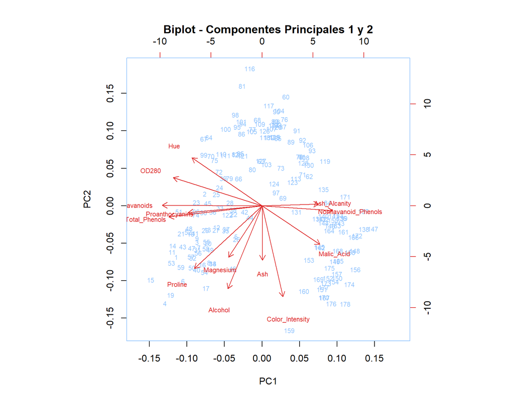

```r
biplot(
  pca_resultado,
  col = c("#93c5fd", "#dc2626"),
  cex = 0.7,
  main = "Biplot - Componentes Principales 1 y 2"
)
```

## 8.10 Hallazgos del PCA

El PCA permitió reducir las **13 variables originales a 6 componentes principales**, conservando aproximadamente el **85.1% de la variabilidad total**.

Los dos primeros componentes explican conjuntamente aproximadamente el **55.41% de la varianza**. Este porcentaje es suficiente para obtener una representación visual útil, pero no para representar por sí solo toda la información que posteriormente será utilizada en el clustering.

En PC1 destacan principalmente las variables **Flavanoids, Total_Phenols, OD280, Proanthocyanins, Nonflavanoid_Phenols**, mientras que en PC2 presentan mayor aporte **Color_Intensity, Alcohol, Proline, Ash, Magnesium**. Esto permite identificar qué características químicas participan con mayor intensidad en las principales direcciones de variación del dataset.

El PCA también complementa los resultados del análisis bivariado, ya que algunas variables que previamente mostraron relaciones importantes vuelven a presentar aportes relevantes dentro de los componentes principales.

Con estos resultados se obtiene una representación reducida que conserva la mayor parte de la información y que puede compararse posteriormente contra el uso directo de las 13 variables estandarizadas.

# 9 Selección del número de clusters

## 9.1 Objetivo

Antes de construir el modelo final es necesario determinar cuántos grupos representan de mejor manera la estructura de los datos.

Para evitar seleccionar arbitrariamente una cantidad de clusters, se evaluaron diferentes valores de `k` mediante dos criterios:

**Método del codo**, basado en la reducción de la suma de cuadrados dentro de los clusters, y **coeficiente de silueta**, que mide simultáneamente qué tan compactas son las observaciones dentro de su grupo y qué tan separadas se encuentran de los demás grupos.

La evaluación se realiza tanto para las variables estandarizadas como para la representación reducida mediante PCA.

## 9.2 Datos PCA para clustering

```r
datos_pca_modelo <- pca_resultado$x[
  ,
  seq_len(cantidad_componentes),
  drop = FALSE
]

cat(
  "Dimensiones utilizadas en PCA + K-Means:",
  ncol(datos_pca_modelo),
  "\n"
)
```

```
## Dimensiones utilizadas en PCA + K-Means: 6
```

## 9.3 Funciones de evaluación

```r
library(cluster)

calcular_wss <- function(
  datos,
  valores_k = 1:10
) {

  sapply(
    valores_k,
    function(k) {

      set.seed(123)

      modelo <- kmeans(
        datos,
        centers = k,
        nstart = 50
      )

      modelo$tot.withinss
    }
  )
}


calcular_silueta <- function(
  datos,
  valores_k = 2:10
) {

  sapply(
    valores_k,
    function(k) {

      set.seed(123)

      modelo <- kmeans(
        datos,
        centers = k,
        nstart = 50
      )

      sil <- silhouette(
        modelo$cluster,
        dist(datos)
      )

      mean(sil[, 3])
    }
  )
}


detectar_codo <- function(
  valores_k,
  valores_wss
) {

  x <- (
    valores_k - min(valores_k)
  ) / (
    max(valores_k) - min(valores_k)
  )

  y <- (
    valores_wss - min(valores_wss)
  ) / (
    max(valores_wss) - min(valores_wss)
  )

  x1 <- x[1]
  y1 <- y[1]

  x2 <- x[length(x)]
  y2 <- y[length(y)]

  distancias <- abs(
    (y2 - y1) * x -
      (x2 - x1) * y +
      x2 * y1 -
      y2 * x1
  ) / sqrt(
    (y2 - y1)^2 +
      (x2 - x1)^2
  )

  valores_k[
    which.max(distancias)
  ]
}
```

## 9.4 Método del codo

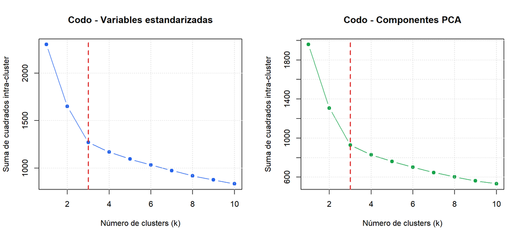

```r
valores_k_codo <- 1:10

wss_estandarizado <- calcular_wss(
  wine_estandarizado,
  valores_k_codo
)

wss_pca <- calcular_wss(
  datos_pca_modelo,
  valores_k_codo
)

k_codo_estandarizado <- detectar_codo(
  valores_k_codo,
  wss_estandarizado
)

k_codo_pca <- detectar_codo(
  valores_k_codo,
  wss_pca
)

par(mfrow = c(1, 2))

plot(
  valores_k_codo,
  wss_estandarizado,
  type = "b",
  pch = 19,
  col = "#2563eb",
  xlab = "Número de clusters (k)",
  ylab = "Suma de cuadrados intra-cluster",
  main = "Codo - Variables estandarizadas"
)

abline(
  v = k_codo_estandarizado,
  col = "#dc2626",
  lty = 2,
  lwd = 2
)

grid()


plot(
  valores_k_codo,
  wss_pca,
  type = "b",
  pch = 19,
  col = "#16a34a",
  xlab = "Número de clusters (k)",
  ylab = "Suma de cuadrados intra-cluster",
  main = "Codo - Componentes PCA"
)

abline(
  v = k_codo_pca,
  col = "#dc2626",
  lty = 2,
  lwd = 2
)

grid()
```

```r
par(mfrow = c(1, 1))
```

## 9.5 Método de silueta

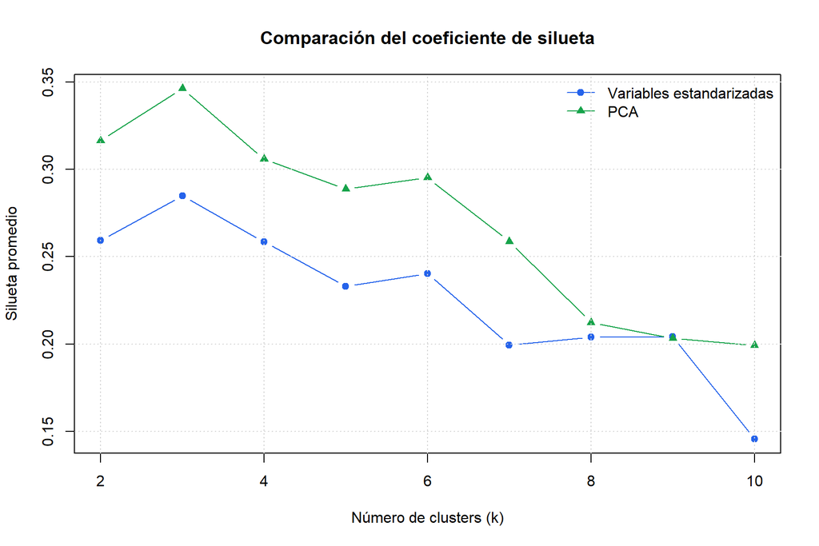

```r
valores_k_silueta <- 2:10

siluetas_estandarizado <- calcular_silueta(
  wine_estandarizado,
  valores_k_silueta
)

siluetas_pca <- calcular_silueta(
  datos_pca_modelo,
  valores_k_silueta
)

k_silueta_estandarizado <- valores_k_silueta[
  which.max(siluetas_estandarizado)
]

k_silueta_pca <- valores_k_silueta[
  which.max(siluetas_pca)
]

plot(
  valores_k_silueta,
  siluetas_estandarizado,
  type = "b",
  pch = 19,
  col = "#2563eb",
  ylim = range(
    c(
      siluetas_estandarizado,
      siluetas_pca
    )
  ),
  xlab = "Número de clusters (k)",
  ylab = "Silueta promedio",
  main = "Comparación del coeficiente de silueta"
)

lines(
  valores_k_silueta,
  siluetas_pca,
  type = "b",
  pch = 17,
  col = "#16a34a"
)

legend(
  "topright",
  legend = c(
    "Variables estandarizadas",
    "PCA"
  ),
  col = c(
    "#2563eb",
    "#16a34a"
  ),
  pch = c(19, 17),
  lty = 1,
  bty = "n"
)

grid()
```

## 9.6 Tabla de evaluación de k

```r
tabla_k <- data.frame(
  K = valores_k_silueta,
  Silueta_Estandarizadas = round(
    siluetas_estandarizado,
    4
  ),
  Silueta_PCA = round(
    siluetas_pca,
    4
  )
)

knitr::kable(
  tabla_k,
  caption = "Coeficiente de silueta para diferentes cantidades de clusters",
  align = c("c", "c", "c")
)
```

Coeficiente de silueta para diferentes cantidades de clusters

| K | Silueta_Estandarizadas | Silueta_PCA |
| --- | --- | --- |
| 2 | 0.2593 | 0.3163 |
| 3 | 0.2849 | 0.3463 |
| 4 | 0.2584 | 0.3059 |
| 5 | 0.2329 | 0.2888 |
| 6 | 0.2404 | 0.2952 |
| 7 | 0.1994 | 0.2587 |
| 8 | 0.2040 | 0.2124 |
| 9 | 0.2042 | 0.2032 |
| 10 | 0.1456 | 0.1992 |

## 9.7 Selección y justificación del número de clusters

```r
cat(
  "Variables estandarizadas\n"
)
```

```
## Variables estandarizadas
```

```r
cat(
  "Codo sugerido: k =",
  k_codo_estandarizado,
  "\n"
)
```

```
## Codo sugerido: k = 3
```

```r
cat(
  "Mejor silueta: k =",
  k_silueta_estandarizado,
  "\n"
)
```

```
## Mejor silueta: k = 3
```

```r
cat(
  "Silueta máxima:",
  round(
    max(siluetas_estandarizado),
    4
  ),
  "\n\n"
)
```

```
## Silueta máxima: 0.2849
```

```r
cat(
  "PCA\n"
)
```

```
## PCA
```

```r
cat(
  "Codo sugerido: k =",
  k_codo_pca,
  "\n"
)
```

```
## Codo sugerido: k = 3
```

```r
cat(
  "Mejor silueta: k =",
  k_silueta_pca,
  "\n"
)
```

```
## Mejor silueta: k = 3
```

```r
cat(
  "Silueta máxima:",
  round(
    max(siluetas_pca),
    4
  ),
  "\n"
)
```

```
## Silueta máxima: 0.3463
```

Para la comparación de modelos se utilizará como criterio principal el **máximo coeficiente de silueta**, debido a que este permite evaluar simultáneamente cohesión y separación.

El método del codo se utiliza como criterio complementario para verificar si existe una reducción importante en la variabilidad interna al aumentar el número de clusters.

En las variables estandarizadas, el método del codo sugiere aproximadamente **k = 3**, mientras que el mayor coeficiente de silueta se obtiene con **k = 3**.

En la representación PCA, el método del codo sugiere aproximadamente **k = 3**, mientras que el mayor coeficiente de silueta se obtiene con **k = 3**.

De esta forma, el número de clusters no se selecciona arbitrariamente, sino a partir de la estructura observada en los datos.

# 10 Comparación de métodos de clustering

## 10.1 K-Means con las variables estandarizadas

```r
k_estandarizado <- k_silueta_estandarizado

set.seed(123)

modelo_kmeans_estandarizado <- kmeans(
  wine_estandarizado,
  centers = k_estandarizado,
  nstart = 50
)

silueta_modelo_estandarizado <- silhouette(
  modelo_kmeans_estandarizado$cluster,
  dist(wine_estandarizado)
)

silueta_promedio_estandarizado <- mean(
  silueta_modelo_estandarizado[, 3]
)

cat(
  "Número de clusters:",
  k_estandarizado,
  "\n"
)
```

```
## Número de clusters: 3
```

```r
cat(
  "Silueta promedio:",
  round(
    silueta_promedio_estandarizado,
    4
  ),
  "\n"
)
```

```
## Silueta promedio: 0.2849
```

```r
cat(
  "Tamaño de clusters:",
  paste(
    modelo_kmeans_estandarizado$size,
    collapse = ", "
  ),
  "\n"
)
```

```
## Tamaño de clusters: 51, 62, 65
```

## 10.2 K-Means con los componentes PCA seleccionados

```r
k_pca <- k_silueta_pca

set.seed(123)

modelo_kmeans_pca <- kmeans(
  datos_pca_modelo,
  centers = k_pca,
  nstart = 50
)

silueta_modelo_pca <- silhouette(
  modelo_kmeans_pca$cluster,
  dist(datos_pca_modelo)
)

silueta_promedio_pca <- mean(
  silueta_modelo_pca[, 3]
)

cat(
  "Componentes utilizados:",
  cantidad_componentes,
  "\n"
)
```

```
## Componentes utilizados: 6
```

```r
cat(
  "Número de clusters:",
  k_pca,
  "\n"
)
```

```
## Número de clusters: 3
```

```r
cat(
  "Silueta promedio:",
  round(
    silueta_promedio_pca,
    4
  ),
  "\n"
)
```

```
## Silueta promedio: 0.3463
```

```r
cat(
  "Tamaño de clusters:",
  paste(
    modelo_kmeans_pca$size,
    collapse = ", "
  ),
  "\n"
)
```

```
## Tamaño de clusters: 51, 62, 65
```

## 10.3 Comparación de resultados

```r
comparacion_modelos <- data.frame(
  Modelo = c(
    "K-Means con variables estandarizadas",
    "PCA + K-Means"
  ),
  Dimensiones = c(
    ncol(wine_estandarizado),
    ncol(datos_pca_modelo)
  ),
  K_Codo = c(
    k_codo_estandarizado,
    k_codo_pca
  ),
  K_Silueta = c(
    k_estandarizado,
    k_pca
  ),
  Silueta_Promedio = round(
    c(
      silueta_promedio_estandarizado,
      silueta_promedio_pca
    ),
    4
  ),
  Tamaño_Clusters = c(
    paste(
      modelo_kmeans_estandarizado$size,
      collapse = " - "
    ),
    paste(
      modelo_kmeans_pca$size,
      collapse = " - "
    )
  )
)

knitr::kable(
  comparacion_modelos,
  caption = "Comparación entre los dos enfoques de clustering",
  align = c(
    "l",
    "c",
    "c",
    "c",
    "c",
    "c"
  )
)
```

Comparación entre los dos enfoques de clustering

| Modelo | Dimensiones | K_Codo | K_Silueta | Silueta_Promedio | Tamaño_Clusters |
| --- | --- | --- | --- | --- | --- |
| K-Means con variables estandarizadas | 13 | 3 | 3 | 0.2849 | 51 - 62 - 65 |
| PCA + K-Means | 6 | 3 | 3 | 0.3463 | 51 - 62 - 65 |

La suma de cuadrados intra-cluster se utiliza para analizar el comportamiento de `k` dentro de cada representación, pero no se utiliza para decidir directamente cuál de los dos modelos es mejor, debido a que ambos trabajan con diferente cantidad de dimensiones.

Para la comparación entre enfoques se utiliza principalmente el **coeficiente de silueta**, acompañado por la reducción de dimensionalidad y la interpretación de los grupos obtenidos.

## 10.4 Similitud entre las dos agrupaciones

Para determinar si ambos enfoques están formando grupos semejantes, se utiliza el **Índice de Rand Ajustado (ARI)**.

Un valor cercano a 1 indica que las dos agrupaciones son muy similares, mientras que valores cercanos a 0 indican una coincidencia mucho menor.

```r
indice_rand_ajustado <- function(
  grupo_1,
  grupo_2
) {

  tabla <- table(
    grupo_1,
    grupo_2
  )

  combinaciones_2 <- function(x) {
    x * (x - 1) / 2
  }

  suma_celdas <- sum(
    combinaciones_2(tabla)
  )

  suma_filas <- sum(
    combinaciones_2(
      rowSums(tabla)
    )
  )

  suma_columnas <- sum(
    combinaciones_2(
      colSums(tabla)
    )
  )

  n <- sum(tabla)

  total_pares <- combinaciones_2(n)

  esperado <- (
    suma_filas *
      suma_columnas
  ) / total_pares

  maximo <- (
    suma_filas +
      suma_columnas
  ) / 2

  if (maximo == esperado) {
    return(1)
  }

  (
    suma_celdas -
      esperado
  ) / (
    maximo -
      esperado
  )
}


ari_modelos <- indice_rand_ajustado(
  modelo_kmeans_estandarizado$cluster,
  modelo_kmeans_pca$cluster
)

cat(
  "Índice de Rand Ajustado:",
  round(ari_modelos, 4),
  "\n"
)
```

```
## Índice de Rand Ajustado: 1
```

```r
tabla_agrupaciones <- table(
  KMeans_Estandarizado =
    modelo_kmeans_estandarizado$cluster,
  KMeans_PCA =
    modelo_kmeans_pca$cluster
)

knitr::kable(
  tabla_agrupaciones,
  caption = "Comparación de las asignaciones entre ambos modelos"
)
```

Comparación de las asignaciones entre ambos modelos

| 1 | 2 | 3 |
| --- | --- | --- |
| 51 | 0 | 0 |
| 0 | 62 | 0 |
| 0 | 0 | 65 |

Los números asignados a los clusters son únicamente etiquetas y no significan que, por ejemplo, el Cluster 1 de un modelo deba corresponder directamente con el Cluster 1 del otro. Por esta razón, el Índice de Rand Ajustado permite realizar una comparación independiente del nombre asignado a cada grupo.

## 10.5 Hallazgos de la comparación

El modelo construido directamente con las 13 variables estandarizadas obtuvo un coeficiente de silueta promedio de **0.2849**, utilizando **3 clusters**.

El modelo basado en los **6 componentes PCA seleccionados** obtuvo una silueta promedio de **0.3463**, utilizando **3 clusters**.

El Índice de Rand Ajustado entre ambos resultados fue de **1**, lo que permite cuantificar hasta qué punto los dos enfoques producen agrupaciones semejantes.

La comparación permite determinar si la reducción dimensional mediante PCA mantiene, mejora o modifica la estructura encontrada utilizando directamente las variables estandarizadas.

# 11 Selección del modelo final

## 11.1 Criterio de selección

Para seleccionar el modelo final se utiliza como criterio principal el coeficiente de silueta promedio.

Un valor mayor indica, en términos generales, una combinación más favorable entre cohesión interna y separación entre los clusters.

```r
if (
  silueta_promedio_pca >
    silueta_promedio_estandarizado
) {

  nombre_modelo_final <- "PCA + K-Means"

  modelo_final <- modelo_kmeans_pca

  datos_modelo_final <- datos_pca_modelo

  k_final <- k_pca

  silueta_promedio_final <-
    silueta_promedio_pca

} else {

  nombre_modelo_final <-
    "K-Means con variables estandarizadas"

  modelo_final <-
    modelo_kmeans_estandarizado

  datos_modelo_final <-
    wine_estandarizado

  k_final <-
    k_estandarizado

  silueta_promedio_final <-
    silueta_promedio_estandarizado
}


cat(
  "Modelo seleccionado:",
  nombre_modelo_final,
  "\n"
)
```

```
## Modelo seleccionado: PCA + K-Means
```

```r
cat(
  "Número de clusters:",
  k_final,
  "\n"
)
```

```
## Número de clusters: 3
```

```r
cat(
  "Coeficiente de silueta:",
  round(
    silueta_promedio_final,
    4
  ),
  "\n"
)
```

```
## Coeficiente de silueta: 0.3463
```

## 11.2 Justificación del modelo seleccionado

El enfoque seleccionado como modelo final es **PCA + K-Means**, ya que obtuvo el mejor coeficiente de silueta entre los dos métodos evaluados.

Su silueta promedio fue de **0.3463**, frente a **0.2849** obtenida por el otro enfoque.

La elección se realiza a partir de los resultados observados y no se presupone que PCA necesariamente debe mejorar el clustering. Su utilidad se determina mediante la comparación directa de ambos modelos.

# 12 Modelo final

## 12.1 Resultados del modelo

```r
cluster_final <- modelo_final$cluster

wine_resultado <- wine[
  ,
  variables_finales,
  drop = FALSE
]

wine_resultado$Cluster <- factor(
  cluster_final
)

tabla_tamanos <- as.data.frame(
  table(
    Cluster = wine_resultado$Cluster
  )
)

names(tabla_tamanos)[2] <- "Cantidad"

tabla_tamanos$Porcentaje <- round(
  tabla_tamanos$Cantidad /
    sum(tabla_tamanos$Cantidad) *
    100,
  2
)

knitr::kable(
  tabla_tamanos,
  caption = "Distribución de las muestras por cluster",
  align = c("c", "c", "c")
)
```

Distribución de las muestras por cluster

| Cluster | Cantidad | Porcentaje |
| --- | --- | --- |
| 1 | 51 | 28.65 |
| 2 | 62 | 34.83 |
| 3 | 65 | 36.52 |

## 12.2 Evaluación de la separación

```r
silueta_final <- silhouette(
  cluster_final,
  dist(datos_modelo_final)
)

interpretar_silueta <- function(valor) {

  if (valor >= 0.50) {
    return("buena")
  }

  if (valor >= 0.25) {
    return("aceptable")
  }

  return("débil")
}

interpretacion_final <- interpretar_silueta(
  silueta_promedio_final
)

cat(
  "Coeficiente de silueta promedio:",
  round(
    silueta_promedio_final,
    4
  ),
  "\n"
)
```

```
## Coeficiente de silueta promedio: 0.3463
```

```r
cat(
  "Interpretación:",
  interpretacion_final,
  "separación entre clusters.\n"
)
```

```
## Interpretación: aceptable separación entre clusters.
```

## 12.3 Gráfico de silueta del modelo final

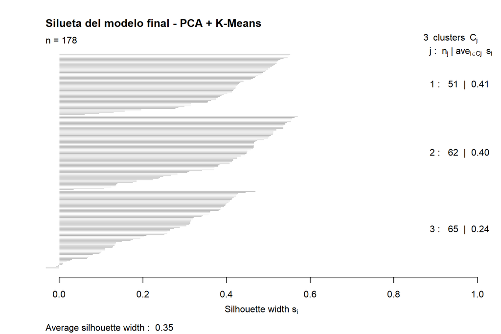

```r
plot(
  silueta_final,
  main = paste(
    "Silueta del modelo final -",
    nombre_modelo_final
  )
)
```

## 12.4 Visualización de los clusters mediante PCA

Independientemente de cuál modelo resulte seleccionado, los clusters pueden proyectarse sobre PC1 y PC2 para facilitar su visualización en dos dimensiones.

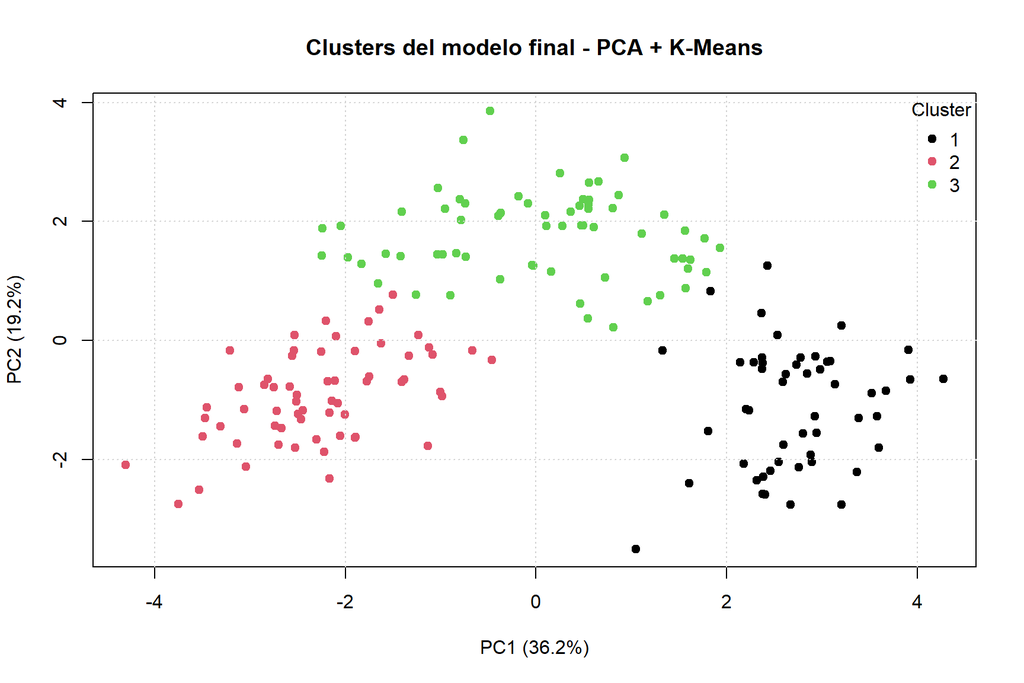

```r
pca_visual <- as.data.frame(
  pca_resultado$x[, 1:2]
)

pca_visual$Cluster <- factor(
  cluster_final
)

plot(
  pca_visual$PC1,
  pca_visual$PC2,
  pch = 19,
  col = as.integer(
    pca_visual$Cluster
  ),
  xlab = paste0(
    "PC1 (",
    round(
      varianza_explicada[1] * 100,
      1
    ),
    "%)"
  ),
  ylab = paste0(
    "PC2 (",
    round(
      varianza_explicada[2] * 100,
      1
    ),
    "%)"
  ),
  main = paste(
    "Clusters del modelo final -",
    nombre_modelo_final
  )
)

legend(
  "topright",
  legend = levels(
    pca_visual$Cluster
  ),
  col = seq_len(k_final),
  pch = 19,
  title = "Cluster",
  bty = "n"
)

grid()
```

## 12.5 Características químicas de cada cluster

Para interpretar los grupos se calculan las medias de las variables originales dentro de cada cluster.

```r
medias_cluster <- aggregate(
  . ~ Cluster,
  data = wine_resultado,
  FUN = mean
)

medias_cluster_presentacion <-
  medias_cluster

medias_cluster_presentacion[
  ,
  -1
] <- round(
  medias_cluster_presentacion[
    ,
    -1
  ],
  2
)

knitr::kable(
  medias_cluster_presentacion,
  caption = "Medias de las características químicas por cluster",
  align = c(
    "c",
    rep(
      "c",
      length(variables_finales)
    )
  )
)
```

Medias de las características químicas por cluster

| Cluster | Alcohol | Malic_Acid | Ash | Ash_Alcanity | Magnesium | Total_Phenols | Flavanoids | Nonflavanoid_Phenols | Proanthocyanins | Color_Intensity | Hue | OD280 | Proline |
| --- | --- | --- | --- | --- | --- | --- | --- | --- | --- | --- | --- | --- | --- |
| 1 | 13.13 | 3.31 | 2.42 | 21.24 | 98.67 | 1.68 | 0.82 | 0.45 | 1.15 | 7.23 | 0.69 | 1.70 | 619.06 |
| 2 | 13.68 | 2.00 | 2.47 | 17.46 | 107.97 | 2.85 | 3.00 | 0.29 | 1.92 | 5.45 | 1.07 | 3.16 | 1100.23 |
| 3 | 12.25 | 1.90 | 2.23 | 20.06 | 92.74 | 2.25 | 2.05 | 0.36 | 1.62 | 2.97 | 1.06 | 2.80 | 510.17 |

## 12.6 Variables que más diferencian los clusters

Para identificar qué variables presentan mayores diferencias entre los grupos se utiliza el estadístico F y el tamaño de efecto `Eta²`.

En este contexto se utilizan de manera **descriptiva**, ya que los propios clusters fueron construidos a partir de estas variables. Por esta razón, el objetivo no es realizar una prueba de significancia independiente, sino determinar qué características muestran una mayor separación entre los grupos obtenidos.

```r
resultados_diferenciacion <- data.frame()

for (variable in variables_finales) {

  modelo_aov <- aov(
    wine_resultado[[variable]] ~
      wine_resultado$Cluster
  )

  tabla_aov <- summary(
    modelo_aov
  )[[1]]

  f_valor <- tabla_aov[
    1,
    "F value"
  ]

  ss_entre <- tabla_aov[
    1,
    "Sum Sq"
  ]

  ss_dentro <- tabla_aov[
    2,
    "Sum Sq"
  ]

  eta2 <- ss_entre /
    (
      ss_entre +
        ss_dentro
    )

  resultados_diferenciacion <- rbind(
    resultados_diferenciacion,
    data.frame(
      Variable = variable,
      F_value = f_valor,
      Eta2 = eta2
    )
  )
}

resultados_diferenciacion <-
  resultados_diferenciacion[
    order(
      resultados_diferenciacion$Eta2,
      decreasing = TRUE
    ),
  ]

resultados_diferenciacion$F_value <-
  round(
    resultados_diferenciacion$F_value,
    2
  )

resultados_diferenciacion$Eta2 <-
  round(
    resultados_diferenciacion$Eta2,
    3
  )

knitr::kable(
  resultados_diferenciacion,
  caption = "Variables ordenadas según su capacidad descriptiva para diferenciar los clusters",
  align = c("l", "c", "c")
)
```

Variables ordenadas según su capacidad descriptiva para diferenciar los clusters

|  | Variable | F_value | Eta2 |
| --- | --- | --- | --- |
| 7 | Flavanoids | 271.59 | 0.756 |
| 12 | OD280 | 221.53 | 0.717 |
| 13 | Proline | 200.31 | 0.696 |
| 1 | Alcohol | 113.17 | 0.564 |
| 10 | Color_Intensity | 111.92 | 0.561 |
| 6 | Total_Phenols | 106.88 | 0.550 |
| 11 | Hue | 104.75 | 0.545 |
| 2 | Malic_Acid | 38.67 | 0.306 |
| 9 | Proanthocyanins | 36.21 | 0.293 |
| 8 | Nonflavanoid_Phenols | 30.98 | 0.262 |
| 4 | Ash_Alcanity | 24.55 | 0.219 |
| 5 | Magnesium | 22.72 | 0.206 |
| 3 | Ash | 14.92 | 0.146 |

```r
top_variables_modelo <-
  head(
    resultados_diferenciacion$Variable,
    5
  )

cat(
  "Variables que más diferencian los clusters:\n"
)
```

```
## Variables que más diferencian los clusters:
```

```r
for (
  i in seq_along(
    top_variables_modelo
  )
) {

  cat(
    i,
    ".",
    top_variables_modelo[i],
    "\n"
  )
}
```

```
## 1 . Flavanoids
## 2 . OD280
## 3 . Proline
## 4 . Alcohol
## 5 . Color_Intensity
```

## 12.7 Comparación de perfiles químicos

Para facilitar la comparación entre clusters se utilizan nuevamente valores estandarizados. Los valores positivos representan características por encima del promedio general y los negativos representan características por debajo del promedio.

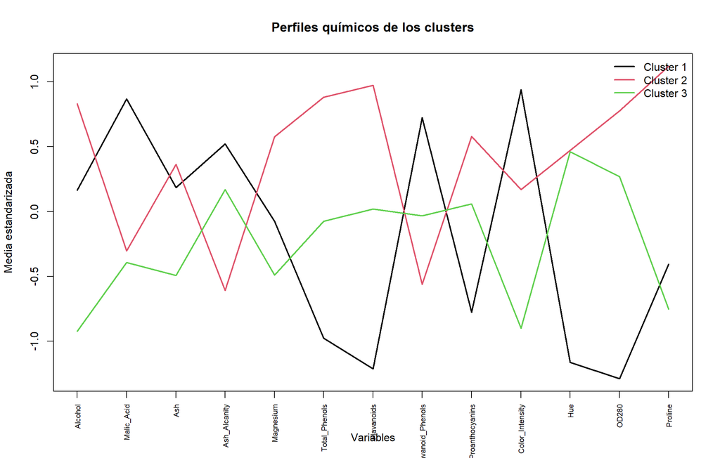

```r
datos_estandarizados_perfil <-
  as.data.frame(
    wine_estandarizado
  )

datos_estandarizados_perfil$Cluster <-
  factor(
    cluster_final
  )

medias_estandarizadas_cluster <-
  aggregate(
    . ~ Cluster,
    data = datos_estandarizados_perfil,
    FUN = mean
  )

matriz_perfiles <-
  as.matrix(
    medias_estandarizadas_cluster[
      ,
      -1
    ]
  )

matplot(
  t(matriz_perfiles),
  type = "l",
  lwd = 2,
  lty = 1,
  col = seq_len(
    nrow(matriz_perfiles)
  ),
  xlab = "Variables",
  ylab = "Media estandarizada",
  main = "Perfiles químicos de los clusters",
  axes = FALSE
)

axis(
  1,
  at = seq_along(
    variables_finales
  ),
  labels = variables_finales,
  las = 2,
  cex.axis = 0.7
)

axis(2)

legend(
  "topright",
  legend = paste(
    "Cluster",
    medias_estandarizadas_cluster$Cluster
  ),
  col = seq_len(
    nrow(matriz_perfiles)
  ),
  lwd = 2,
  bty = "n"
)

box()
```

## 12.8 Resumen de los perfiles por cluster

```r
resumen_perfiles <- do.call(
  rbind,
  lapply(
    seq_len(
      nrow(
        medias_estandarizadas_cluster
      )
    ),
    function(i) {

      valores <- as.numeric(
        medias_estandarizadas_cluster[
          i,
          -1
        ]
      )

      names(valores) <-
        variables_finales

      variables_altas <- names(
        sort(
          valores,
          decreasing = TRUE
        )
      )[1:3]

      variables_bajas <- names(
        sort(
          valores,
          decreasing = FALSE
        )
      )[1:3]

      data.frame(
        Cluster =
          medias_estandarizadas_cluster$Cluster[i],

        Caracteristicas_mas_altas =
          paste(
            variables_altas,
            collapse = ", "
          ),

        Caracteristicas_mas_bajas =
          paste(
            variables_bajas,
            collapse = ", "
          )
      )
    }
  )
)

knitr::kable(
  resumen_perfiles,
  caption = "Características químicas que destacan en cada cluster",
  align = c("c", "l", "l")
)
```

Características químicas que destacan en cada cluster

| Cluster | Caracteristicas_mas_altas | Caracteristicas_mas_bajas |
| --- | --- | --- |
| 1 | Color_Intensity, Malic_Acid, Nonflavanoid_Phenols | OD280, Flavanoids, Hue |
| 2 | Proline, Flavanoids, Total_Phenols | Ash_Alcanity, Nonflavanoid_Phenols, Malic_Acid |
| 3 | Hue, OD280, Ash_Alcanity | Alcohol, Color_Intensity, Proline |

## 12.9 Hallazgos del modelo

El modelo final seleccionado fue **PCA + K-Means** y permitió identificar **3 grupos de vinos**.

La distribución de las muestras entre los clusters fue de **51, 62, 65 vinos**, respectivamente.

El coeficiente de silueta promedio obtenido fue de **0.3463**, lo que corresponde a una separación **aceptable** según el criterio utilizado en este análisis.

Las variables que presentan las mayores diferencias entre los perfiles obtenidos son **Flavanoids, OD280, Proline, Alcohol, Color_Intensity**.

El análisis de las medias estandarizadas permite observar que los grupos no representan niveles de calidad, sino **perfiles químicos diferentes**. Cada cluster combina de manera distinta las características medidas en las muestras de vino.

Estos perfiles permiten responder la problemática desde una perspectiva de similitud química, identificando qué muestras comparten características y cuáles variables contribuyen principalmente a diferenciarlas.

# 13 Respuesta a las preguntas de análisis

## 13.1 Pregunta principal

### 13.1.1 ¿Es posible identificar grupos de vinos con características químicas similares y determinar cuáles variables contribuyen más a diferenciarlos?

Sí. El análisis permitió identificar **3 grupos de vinos** mediante el modelo **PCA + K-Means**.

Las variables que muestran una mayor capacidad para diferenciar los perfiles obtenidos son **Flavanoids, OD280, Proline, Alcohol, Color_Intensity**.

El coeficiente de silueta del modelo final fue de **0.3463**, lo que indica una separación **aceptable** entre los grupos.

## 13.2 Pregunta 1: ¿Cuáles variables presentan mayor variabilidad y podrían contribuir más a diferenciar las muestras?

Las variables originales presentan escalas muy diferentes, por lo que comparar directamente sus desviaciones estándar puede dar mayor importancia a las variables con valores numéricos grandes.

Por esta razón se realizó la estandarización antes del modelado.

Después del análisis completo, las características que mostraron mayores diferencias entre los clusters fueron **Flavanoids, OD280, Proline, Alcohol, Color_Intensity**.

## 13.3 Pregunta 2: ¿Qué comportamiento presentan las variables que mostraron posibles valores atípicos?

Durante el análisis exploratorio se detectaron valores atípicos mediante el método IQR en varias variables, especialmente en `Ash_Alcanity`, `Magnesium` y `Color_Intensity`.

Estos valores fueron conservados porque no se encontró evidencia suficiente para considerarlos errores de registro y su eliminación automática podría eliminar información real relacionada con la variabilidad química de las muestras.

## 13.4 Pregunta 3: ¿Los posibles valores atípicos representan casos aislados o forman parte del comportamiento natural de las variables?

La comparación realizada durante el análisis preexploratorio mostró que retirar temporalmente las observaciones con posibles outliers no modificaba de manera extrema el comportamiento general de las variables.

Por esta razón, los valores fueron tratados como posibles observaciones naturales del dataset y se conservaron para el modelado.

## 13.5 Pregunta 4: ¿Qué variables presentan distribuciones asimétricas?

El análisis univariado mostró que `Proline` y `Malic_Acid` presentan una asimetría positiva más marcada que otras características, observable tanto en sus histogramas como en las diferencias entre media y mediana.

Estas características fueron conservadas y posteriormente estandarizadas antes del clustering.

## 13.6 Pregunta 5: ¿Qué relaciones existen entre las características químicas?

```r
matriz_correlacion_modelado <- cor(
  wine[
    ,
    variables_finales
  ],
  use = "complete.obs"
)

posiciones_correlacion <- which(
  upper.tri(
    matriz_correlacion_modelado
  ),
  arr.ind = TRUE
)

valores_correlacion <-
  matriz_correlacion_modelado[
    posiciones_correlacion
  ]

posicion_maxima <- which.max(
  abs(
    valores_correlacion
  )
)

variable_correlacion_1 <-
  rownames(
    matriz_correlacion_modelado
  )[
    posiciones_correlacion[
      posicion_maxima,
      1
    ]
  ]

variable_correlacion_2 <-
  colnames(
    matriz_correlacion_modelado
  )[
    posiciones_correlacion[
      posicion_maxima,
      2
    ]
  ]

correlacion_principal <-
  valores_correlacion[
    posicion_maxima
  ]
```

La relación lineal más intensa del dataset se presenta entre **Total_Phenols y Flavanoids**, con una correlación aproximada de **0.865**.

El análisis bivariado mostró además que existen grupos de variables relacionadas con los compuestos fenólicos que comparten parte de su información, aunque no se encontraron correlaciones perfectas que justificaran eliminar automáticamente alguna característica.

## 13.7 Pregunta 6: ¿Era necesaria la estandarización antes del clustering?

Sí.

Las diferencias de escala entre las variables podían hacer que características con valores numéricos grandes dominaran las distancias utilizadas por K-Means.

La estandarización permitió que las 13 variables participaran en una escala comparable tanto en PCA como en K-Means.

## 13.8 Pregunta 7: ¿Se pueden observar patrones o agrupaciones naturales entre las muestras?

Sí.

Los métodos de selección de `k` y el modelado posterior permitieron identificar **3 clusters** con perfiles químicos diferenciados.

La evaluación final obtuvo una silueta promedio de **0.3463**, y las características químicas de cada grupo presentan diferencias que permiten interpretar los clusters como perfiles distintos dentro del dataset.

# 14 Hallazgos generales

## 14.1 Calidad y estructura de los datos

El dataset contiene **178 muestras y 13 variables químicas numéricas**.

No se encontraron valores faltantes ni registros duplicados, por lo que no fue necesario realizar imputación de datos ni eliminar observaciones repetidas antes del análisis.

## 14.2 Distribuciones y valores atípicos

El análisis univariado permitió identificar diferencias importantes entre las distribuciones de las variables.

`Proline` y `Malic_Acid` presentan una asimetría positiva más marcada, mientras que otras características presentan distribuciones más cercanas a la simetría.

También se detectaron posibles valores atípicos en varias variables. Sin embargo, la comparación realizada durante el análisis preexploratorio indicó que su impacto sobre las estadísticas generales era limitado y no existía evidencia suficiente para eliminarlos automáticamente.

## 14.3 Relaciones entre variables

El análisis bivariado mostró que algunas características químicas presentan asociaciones importantes.

La relación más fuerte se encontró entre **Total_Phenols y Flavanoids**, con una correlación aproximada de **0.865**.

Estas relaciones muestran que existe información compartida entre algunas características, pero no se encontraron correlaciones perfectas que justificaran eliminar variables antes del modelado.

## 14.4 Estandarización

Las diferencias de escala observadas durante el EDA confirmaron la necesidad de estandarizar los datos.

Este procedimiento evitó que variables con magnitudes numéricas mayores tuvieran una influencia desproporcionada en los algoritmos basados en distancias.

## 14.5 PCA

El PCA permitió reducir las **13 variables originales a 6 componentes principales**, conservando aproximadamente el **85.1% de la varianza total**.

Esto demuestra que una parte importante de la información original puede representarse utilizando menos dimensiones.

Las variables con mayor aporte en PC1 fueron **Flavanoids, Total_Phenols, OD280, Proanthocyanins, Nonflavanoid_Phenols**, mientras que PC2 estuvo principalmente influenciado por **Color_Intensity, Alcohol, Proline, Ash, Magnesium**.

## 14.6 Selección del número de clusters

La cantidad de clusters fue evaluada mediante el método del codo y el coeficiente de silueta.

En lugar de seleccionar `k` arbitrariamente, se compararon diferentes cantidades de grupos para identificar la estructura con mejor equilibrio entre cohesión y separación.

El modelo final utiliza **3 clusters**.

## 14.7 Comparación entre K-Means y PCA + K-Means

K-Means utilizando directamente las 13 variables estandarizadas obtuvo una silueta promedio de **0.2849**.

PCA + K-Means, utilizando 6 componentes principales, obtuvo una silueta promedio de **0.3463**.

El Índice de Rand Ajustado entre ambos resultados fue **1**, mostrando el nivel de similitud entre las agrupaciones producidas por ambos enfoques.

El modelo seleccionado finalmente fue **PCA + K-Means**, ya que presentó el mejor resultado según el criterio de silueta utilizado.

## 14.8 Perfiles químicos

El modelo final permitió identificar grupos con características químicas diferenciadas.

Las variables que presentan las mayores diferencias entre clusters son **Flavanoids, OD280, Proline, Alcohol, Color_Intensity**.

Los resultados no representan niveles de calidad del vino, sino distintos **perfiles químicos** dentro de las muestras analizadas.

## 14.9 Hallazgo integrador

Los resultados obtenidos en las diferentes etapas se complementan entre sí.

El EDA permitió identificar relaciones, diferencias de escala, asimetrías y posibles valores atípicos; PCA permitió resumir la información y detectar las principales direcciones de variación; y el clustering permitió transformar estas diferencias en grupos concretos de muestras con perfiles químicos similares.

La comparación entre K-Means directo y PCA + K-Means permitió además comprobar si la reducción de dimensionalidad aportaba una mejora real al proceso, en lugar de asumir previamente que utilizar PCA produciría necesariamente mejores clusters.

# 15 Conclusiones generales

El análisis permitió cumplir el objetivo principal del proyecto al estudiar las características químicas de las muestras e identificar grupos de vinos con perfiles semejantes mediante técnicas de aprendizaje no supervisado.

La etapa exploratoria mostró que el dataset presenta buena calidad, sin valores faltantes ni registros duplicados. También permitió identificar diferencias importantes de escala, algunas distribuciones asimétricas, posibles valores atípicos y relaciones relevantes entre determinadas características químicas. Estos resultados justificaron conservar las 13 variables y realizar una estandarización antes del modelado.

El PCA permitió reducir las 13 variables originales a **6 componentes**, conservando aproximadamente el **85.1% de la varianza total**. Esta reducción permitió construir una segunda representación del dataset y evaluar si K-Means podía obtener una estructura más clara utilizando menos dimensiones.

La cantidad de clusters fue seleccionada mediante la combinación del método del codo y el coeficiente de silueta, evitando establecer el número de grupos de forma arbitraria. Finalmente se utilizaron **3 clusters** en el modelo seleccionado.

La comparación entre los dos enfoques mostró que K-Means con las variables estandarizadas obtuvo una silueta de **0.2849**, mientras que PCA + K-Means obtuvo **0.3463**. A partir de estos resultados se seleccionó **PCA + K-Means** como modelo final.

Las características que más contribuyen a diferenciar los grupos obtenidos son **Flavanoids, OD280, Proline, Alcohol, Color_Intensity**. Los clusters representan diferentes combinaciones de características químicas y no deben interpretarse como categorías de alta, media o baja calidad, ya que el dataset no contiene una variable que permita establecer niveles de calidad.

En conjunto, el proyecto demuestra que es posible identificar estructuras y perfiles químicos dentro de las muestras mediante técnicas exploratorias, reducción de dimensionalidad y clustering. Además, la comparación de dos estrategias de K-Means permite fundamentar la selección del modelo a partir de resultados medibles y no únicamente de una representación visual.

Como limitación, el análisis se realiza sobre 178 muestras y no dispone de una variable externa de referencia que permita validar los grupos como categorías reales de calidad o clasificación comercial. Como trabajo futuro sería posible evaluar otros algoritmos de clustering, utilizar nuevas muestras o incorporar variables adicionales para estudiar si los perfiles identificados se mantienen en conjuntos de datos diferentes.